# NCDB Sinus SCCa

metastases

Jason Brant

June 25, 2019

# Summary

## Updates

1. **2017 07 14:**
- Initial analysis

**Note: To hide the code from this document, click the button in the upper right corner.**

```r
col.width <- c(37, 10, 1, 1, 3, 1, 2, 1, 2, 1, 1, 1, 1, 1, 1, 8, 2, 2, 2, 4, 4, 1, 4, 1, 1, 1, 3, 2, 2, 8,
               2, 5, 5, 5, 4, 5, 5, 5, 4, 2, 1, 2, 1, 3, 1, 1, 1, 1, 1, 1, 3, 3, 3, 3, 3, 3, 3, 3, 3, 3, 3,
               3, 3, 3, 3, 3, 3, 3, 3, 3, 3, 3, 3, 3, 3, 6, 8, 8, 8, 2, 1, 1, 1, 1, 8, 1, 1, 8, 1, 1, 2,
               2, 5, 2, 5, 3, 1, 3, 1, 8, 8, 2, 8, 2, 8, 2, 2, 1, 8, 1, 1, 1, 1, 1, 8, 1, 2, 2, 2, 2, 2,
               1, 1, 1, 2, 1)
col.names.abr <- c("PUF_CASE_ID", "PUF_FACILITY_ID", "FACILITY_TYPE_CD",  "FACILITY_LOCATION_CD", "AGE", "SEX", "RACE",
                   "SPANISH_HISPANIC_ORIGIN", "INSURANCE_STATUS", "MED_INC_QUAR_00", "NO_HSD_QUAR_00", "UR_CD_03",
                   "MED_INC_QUAR_12", "NO_HSD_QUAR_12", "UR_CD_13", "CROWFLY", "CDCC_TOTAL", "SEQUENCE_NUMBER",
                   "CLASS_OF_CASE", "YEAR_OF_DIAGNOSIS", "PRIMARY_SITE",  "LATERALITY", "HISTOLOGY", "BEHAVIOR",
                   "GRADE", "DIAGNOSTIC_CONFIRMATION", "TUMOR_SIZE", "REGIONAL_NODES_POSITIVE",
                   "REGIONAL_NODES_EXAMINED", "DX_STAGING_PROC_DAYS", "RX_SUMM_DXSTG_PROC", "TNM_CLIN_T",
                   "TNM_CLIN_N", "TNM_CLIN_M", "TNM_CLIN_STAGE_GROUP", "TNM_PATH_T", "TNM_PATH_N", "TNM_PATH_M",
                   "TNM_PATH_STAGE_GROUP", "TNM_EDITION_NUMBER", "ANALYTIC_STAGE_GROUP", "CS_METS_AT_DX",
                   "CS_METS_EVAL", "CS_EXTENSION", "CS_TUMOR_SIZEEXT_EVAL", "CS_METS_DX_BONE",
                   "CS_METS_DX_BRAIN", "CS_METS_DX_LIVER", "CS_METS_DX_LUNG", "LYMPH_VASCULAR_INVASION",
                   "CS_SITESPECIFIC_FACTOR_1", "CS_SITESPECIFIC_FACTOR_2", "CS_SITESPECIFIC_FACTOR_3",
                   "CS_SITESPECIFIC_FACTOR_4", "CS_SITESPECIFIC_FACTOR_5", "CS_SITESPECIFIC_FACTOR_6",
                   "CS_SITESPECIFIC_FACTOR_7", "CS_SITESPECIFIC_FACTOR_8", "CS_SITESPECIFIC_FACTOR_9",
                   "CS_SITESPECIFIC_FACTOR_10", "CS_SITESPECIFIC_FACTOR_11", "CS_SITESPECIFIC_FACTOR_12",
                   "CS_SITESPECIFIC_FACTOR_13", "CS_SITESPECIFIC_FACTOR_14", "CS_SITESPECIFIC_FACTOR_15",
                   "CS_SITESPECIFIC_FACTOR_16", "CS_SITESPECIFIC_FACTOR_17", "CS_SITESPECIFIC_FACTOR_18",
                   "CS_SITESPECIFIC_FACTOR_19", "CS_SITESPECIFIC_FACTOR_20", "CS_SITESPECIFIC_FACTOR_21",
                   "CS_SITESPECIFIC_FACTOR_22", "CS_SITESPECIFIC_FACTOR_23", "CS_SITESPECIFIC_FACTOR_24",
                   "CS_SITESPECIFIC_FACTOR_25", "CS_VERSION_LATEST", "DX_RX_STARTED_DAYS",
                   "DX_SURG_STARTED_DAYS", "DX_DEFSURG_STARTED_DAYS", "RX_SUMM_SURG_PRIM_SITE",
                   "RX_HOSP_SURG_APPR_2010", "RX_SUMM_SURGICAL_MARGINS", "RX_SUMM_SCOPE_REG_LN_SUR",
                   "RX_SUMM_SURG_OTH_REGDIS", "SURG_DISCHARGE_DAYS", "READM_HOSP_30_DAYS",
                   "REASON_FOR_NO_SURGERY", "DX_RAD_STARTED_DAYS", "RX_SUMM_RADIATION", "RAD_LOCATION_OF_RX",
                   "RAD_TREAT_VOL", "RAD_REGIONAL_RX_MODALITY", "RAD_REGIONAL_DOSE_CGY",
                   "RAD_BOOST_RX_MODALITY", "RAD_BOOST_DOSE_CGY", "RAD_NUM_TREAT_VOL",
                   "RX_SUMM_SURGRAD_SEQ", "RAD_ELAPSED_RX_DAYS", "REASON_FOR_NO_RADIATION",
                   "DX_SYSTEMIC_STARTED_DAYS", "DX_CHEMO_STARTED_DAYS", "RX_SUMM_CHEMO",
                   "DX_HORMONE_STARTED_DAYS", "RX_SUMM_HORMONE", "DX_IMMUNO_STARTED_DAYS",
                   "RX_SUMM_IMMUNOTHERAPY", "RX_SUMM_TRNSPLNT_ENDO", "RX_SUMM_SYSTEMIC_SUR_SEQ",
                   "DX_OTHER_STARTED_DAYS", "RX_SUMM_OTHER", "PALLIATIVE_CARE", "RX_SUMM_TREATMENT_STATUS",
                   "PUF_30_DAY_MORT_CD", "PUF_90_DAY_MORT_CD", "DX_LASTCONTACT_DEATH_MONTHS",
                   "PUF_VITAL_STATUS", "RX_HOSP_SURG_PRIM_SITE", "RX_HOSP_CHEMO", "RX_HOSP_IMMUNOTHERAPY",
                   "RX_HOSP_HORMONE", "RX_HOSP_OTHER", "PUF_MULT_SOURCE", "REFERENCE_DATE_FLAG",
                   "RX_SUMM_SCOPE_REG_LN_2012", "RX_HOSP_DXSTG_PROC", "PALLIATIVE_CARE_HOSP")
#Read in data for each subsite
bone.joint <- read_fwf('I:/Brant/Research/NCDB/Data/Data_2017/NCDB_PUF_DATA_Nov-07-2017/NCDBPUF_BoneJont.3.2015.0.dat',
                       fwf_widths(col.width, col_names = col.names.abr),
                       col_types = cols(.default = col_character()))
brain <- read_fwf('I:/Brant/Research/NCDB/Data/Data_2017/NCDB_PUF_DATA_Nov-07-2017/NCDBPUF_Brain.3.2015.0.dat',
                       fwf_widths(col.width, col_names = col.names.abr),
                       col_types = cols(.default = col_character()))
cns <- read_fwf('I:/Brant/Research/NCDB/Data/Data_2017/NCDB_PUF_DATA_Nov-07-2017/NCDBPUF_CNS.3.2015.0.dat',
                       fwf_widths(col.width, col_names = col.names.abr),
                       col_types = cols(.default = col_character()))
gum.ot.mth <- read_fwf('I:/Brant/Research/NCDB/Data/Data_2017/NCDB_PUF_DATA_Nov-07-2017/NCDBPUF_GumOtMth.3.2015.0.dat',
                       fwf_widths(col.width, col_names = col.names.abr),
                       col_types = cols(.default = col_character()))
hypophar <- read_fwf('I:/Brant/Research/NCDB/Data/Data_2017/NCDB_PUF_DATA_Nov-07-2017/NCDBPUF_Hypophar.3.2015.0.dat',
                       fwf_widths(col.width, col_names = col.names.abr),
                       col_types = cols(.default = col_character()))
larynx <- read_fwf('I:/Brant/Research/NCDB/Data/Data_2017/NCDB_PUF_DATA_Nov-07-2017/NCDBPUF_Larynx.3.2015.0.dat',
                       fwf_widths(col.width, col_names = col.names.abr),
                       col_types = cols(.default = col_character()))
lip <- read_fwf('I:/Brant/Research/NCDB/Data/Data_2017/NCDB_PUF_DATA_Nov-07-2017/NCDBPUF_Lip.3.2015.0.dat',
                       fwf_widths(col.width, col_names = col.names.abr),
                       col_types = cols(.default = col_character()))
melanoma <- read_fwf('I:/Brant/Research/NCDB/Data/Data_2017/NCDB_PUF_DATA_Nov-07-2017/NCDBPUF_Melanoma.3.2015.0.dat',
                       fwf_widths(col.width, col_names = col.names.abr),
                       col_types = cols(.default = col_character()))
fom <- read_fwf('I:/Brant/Research/NCDB/Data/Data_2017/NCDB_PUF_DATA_Nov-07-2017/NCDBPUF_MouthFlr.3.2015.0.dat',
                       fwf_widths(col.width, col_names = col.names.abr),
                       col_types = cols(.default = col_character()))
nasal <- read_fwf('I:/Brant/Research/NCDB/Data/Data_2017/NCDB_PUF_DATA_Nov-07-2017/NCDBPUF_Nasal.3.2015.0.dat',
                       fwf_widths(col.width, col_names = col.names.abr),
                       col_types = cols(.default = col_character()))
nasophar <- read_fwf('I:/Brant/Research/NCDB/Data/Data_2017/NCDB_PUF_DATA_Nov-07-2017/NCDBPUF_Nasophar.3.2015.0.dat',
                       fwf_widths(col.width, col_names = col.names.abr),
                       col_types = cols(.default = col_character()))
orophar <- read_fwf('I:/Brant/Research/NCDB/Data/Data_2017/NCDB_PUF_DATA_Nov-07-2017/NCDBPUF_Orophary.3.2015.0.dat',
                       fwf_widths(col.width, col_names = col.names.abr),
                       col_types = cols(.default = col_character()))
oth.endo <- read_fwf('I:/Brant/Research/NCDB/Data/Data_2017/NCDB_PUF_DATA_Nov-07-2017/NCDBPUF_OtEndocr.3.2015.0.dat',
                       fwf_widths(col.width, col_names = col.names.abr),
                       col_types = cols(.default = col_character()))
skin <- read_fwf('I:/Brant/Research/NCDB/Data/Data_2017/NCDB_PUF_DATA_Nov-07-2017/NCDBPUF_OtSkin.3.2015.0.dat',
                       fwf_widths(col.width, col_names = col.names.abr),
                       col_types = cols(.default = col_character()))
pharynx <- read_fwf('I:/Brant/Research/NCDB/Data/Data_2017/NCDB_PUF_DATA_Nov-07-2017/NCDBPUF_Pharynx.3.2015.0.dat',
                       fwf_widths(col.width, col_names = col.names.abr),
                       col_types = cols(.default = col_character()))
saliv.gland <- read_fwf('I:/Brant/Research/NCDB/Data/Data_2017/NCDB_PUF_DATA_Nov-07-2017/NCDBPUF_SalivGld.3.2015.0.dat',
                       fwf_widths(col.width, col_names = col.names.abr),
                       col_types = cols(.default = col_character()))
thyroid <- read_fwf('I:/Brant/Research/NCDB/Data/Data_2017/NCDB_PUF_DATA_Nov-07-2017/NCDBPUF_Thyroid.3.2015.0.dat',
                       fwf_widths(col.width, col_names = col.names.abr),
                       col_types = cols(.default = col_character()))
tongue <- read_fwf('I:/Brant/Research/NCDB/Data/Data_2017/NCDB_PUF_DATA_Nov-07-2017/NCDBPUF_Tongue.3.2015.0.dat',
                       fwf_widths(col.width, col_names = col.names.abr),
                       col_types = cols(.default = col_character()))
tonsil <- read_fwf('I:/Brant/Research/NCDB/Data/Data_2017/NCDB_PUF_DATA_Nov-07-2017/NCDBPUF_Tonsil.3.2015.0.dat',
                       fwf_widths(col.width, col_names = col.names.abr),
                       col_types = cols(.default = col_character()))
trach.med <- read_fwf('I:/Brant/Research/NCDB/Data/Data_2017/NCDB_PUF_DATA_Nov-07-2017/NCDBPUF_TrachMed.3.2015.0.dat',
                       fwf_widths(col.width, col_names = col.names.abr),
                       col_types = cols(.default = col_character()))
#Combine data for all subsites
dat <- bind_rows(bone.joint, brain, cns, gum.ot.mth, hypophar, larynx, lip, melanoma, fom, nasal, nasophar, orophar,
                 oth.endo, skin, pharynx, saliv.gland, thyroid, tongue, tonsil, trach.med)
rm(bone.joint, brain, cns, gum.ot.mth, hypophar, larynx, lip, melanoma, fom, nasal, nasophar, orophar,
                 oth.endo, skin, pharynx, saliv.gland, thyroid, tongue, tonsil, trach.med)
prim_site_text <- data_frame(PRIMARY_SITE = c("C030", "C031", "C062", "C039", "C050", "C051", "C052", "C058", "C059", "C068",
               "C069", "C060", "C061", "C129", "C130", "C131", "C132", "C138", "C139", "C320",
               "C321", "C322", "C323", "C328", "C329", "C000", "C003", "C001", "C004", "C006",
               "C002", "C005", "C008", "C009", "C440", "C442", "C443", "C444", "C445", "C446",
               "C447", "C448", "C449", "C441", "C040", "C041", "C048", "C049", "C300", "C301",
               "C310", "C311", "C312", "C313", "C318", "C319", "C110", "C111", "C112", "C113",
               "C118", "C119", "C090", "C091", "C098", "C099", "C100", "C102", "C103", "C104",
               "C108", "C109", "C101", "C140", "C142", "C148", "C079", "C080", "C081", "C088",
               "C089", "C739", "C019", "C024", "C020", "C021", "C022", "C023", "C028", "C029"),
               SITE_TEXT = c("C03.0: Gum, upper", "C03.1 Gum, lower", "C06.2 Retromolar area", "C03.9 Gum, NOS",
               "C05.0 Hard Palate", "C05.1 Soft Palate", "C05.2 Uvula", "C05.8 Overlapping lesion of palate",
               "C05.9 Palate NOS", "C06.8 Overlapping lesion of other an unspecified parts of mouth",
               "C06.9 Mouth, NOS", "C06.0 Buccal mucosa", "C06.1 Vestibule of mouth", "C12.9  Pyriform sinus",
               "C13.0  Postcricoid region", "C13.1  Hypopharyngeal aspect of aryepiglottic fold",
               "C13.2  Posterior wall of hypopharynx", "C13.8  Overlapping lesion of hypopharynx",
               "C13.9  Hypopharynx, NOS (laryngopharynx)", "C32.0  Glottis", "C32.1  Supraglottis",
               "C32.2  Subglottis", "C32.3  Laryngeal cartilage", "C32.8  Overlapping lesion of larynx",
               "C32.9  Larynx, NOS", "C00.0  External upper lip (vermilion)", "C00.3  Mucosa of upper lip",
               "C00.1  External lower lip (vermilion)", "C00.4  Mucosa of lower lip", "C00.6  Commissure of lip",
               "C00.2  External lip, NOS (vermilion)", "C00.5  Mucosa of lip, NOS", "C00.8  Overlapping lesion of lip",
               "C00.9  Lip, NOS (excludes skin of lip C44.0)", "C44.0  Skin of lip, NOS", "C44.2  External ear",
               "C44.3  Skin of other and unspecified parts of face", "C44.4  Skin of scalp and neck",
               "C44.5  Skin of trunk", "C44.6  Skin of upper limb and shoulder", "C44.7  Skin of lower limb and hip",
               "C44.8  Overlapping lesion of skin", "C44.9  Skin, NOS", "C44.1 Eyelid",
```

```r
               "C04.0  Anterior floor of mouth", "C04.1  Lateral floor of mouth", "C04.8  Overlapping lesion of floor of mouth",
               "C04.9  Floor of mouth, NOS", "C30.0  Nasal cavity (excluding nose, NOS C76.0)", "C30.1  Middle ear",
               "C31.0  Maxillary sinus", "C31.1  Ethmoid sinus", "C31.2  Frontal sinus", "C31.3  Sphenoid sinus",
               "C31.8  Overlapping lesion of accessory sinuses", "C31.9  Accessory sinus, NOS",
               "C11.0  Superior wall of nasopharynx", "C11.1  Posterior wall of nasopharynx (excluding pharyngeal tonsil)",
               "C11.2  Lateral wall of nasopharynx", "C11.3  Anterior wall of nasopharynx",
               "C11.8  Overlapping lesion of nasopharynx", "C11.9  Nasopharynx, NOS", "C09.0  Tonsillar fossa",
               "C09.1  Tonsillar pillar", "C09.8  Overlapping lesion of tonsil",
               "C09.9  Tonsil, NOS (excluding lingual tonsil C02.4)", "C10.0  Vallecula",
               "C10.2  Lateral wall of oropharynx", "C10.3  Posterior wall of oropharynx",
               "C10.4  Branchial cleft (site of neoplasm)", "C10.8  Overlapping lesion of oropharynx",
               "C10.9  Oropharynx, NOS", "C10.1  Anterior surface of epiglottis", "C14.0  Pharynx, NOS",
               "C14.2  Waldeyer ring", "C14.8  Overlapping lesion of lip, oral cavity", "C07.9  Parotid gland",
               "C08.0  Submandibular gland", "C08.1  Sublingual gland", "C08.8  Overlapping lesion of major salivary glands",
               "C08.9  Major salivary gland, NOS", "C73.9  Thyroid gland", "C01.9  Base of tongue, NOS",
               "C02.4  Lingual tonsil", "C02.0  Dorsal surface of tongue, NOS", "C02.1  Border of tongue (Tip)",
               "C02.2  Ventral surface of tongue, NOS", "C02.3  Anterior 2/3 of tongue, NOS",
               "C02.8  Overlapping lesion of tongue", "C02.9  Tongue, NOS"),
               CS_GROUP = c("gum_upper", "gum_lower", "gum_lower", "gum_nos", "hard_palate", "soft_palate",
             "soft_palate", "other_mouth", "other_mouth", "other_mouth", "other_mouth",
             "buccal", "buccal", "hypopharynx", "hypopharynx", "hypopharynx", "hypopharynx",
             "hypopharynx", "hypopharynx", "glottis", "supraglot", "subglot", "lx_oth",
             "lx_oth", "lx_oth", "up_lip", "up_lip", "low_lip", "low_lip", "low_lip",
             "lip_oth", "lip_oth", "lip_oth", "lip_oth", "skin", "skin", "skin", "skin",
             "skin", "skin", "skin", "skin", "skin", "eyelid", "fom", "fom", "fom", "fom",
             "nasal_cavity", "mid_ear", "max_sin", "eth_sin", "oth_sin", "oth_sin",
             "oth_sin", "oth_sin", "np", "np", "np", "np", "np", "np", "op",
             "op", "op", "op", "op", "op", "op", "op", "op", "op", "ant_epi",
             "oth_phary", "oth_phary", "oth_phary", "parotid", "smglnd",
             "glnd_oth", "glnd_oth", "glnd_oth", "thyroid", "bot_lt",
             "bot_lt", "tongue_oth", "tongue_oth", "tongue_oth", "tongue_oth",
             "tongue_oth", "tongue_oth"))
dat <- merge(dat, prim_site_text, by = "PRIMARY_SITE", all.x = TRUE)
rm(prim_site_text)
fact_vars <- c("PRIMARY_SITE", "FACILITY_TYPE_CD", "FACILITY_LOCATION_CD", "SEX", "RACE", "SPANISH_HISPANIC_ORIGIN",
               "INSURANCE_STATUS", "MED_INC_QUAR_00", "NO_HSD_QUAR_00", "UR_CD_03", "MED_INC_QUAR_12",
               "NO_HSD_QUAR_12", "UR_CD_13", "CDCC_TOTAL", "SEQUENCE_NUMBER", "CLASS_OF_CASE",
               "YEAR_OF_DIAGNOSIS", "LATERALITY", "HISTOLOGY", "BEHAVIOR",
               "GRADE", "DIAGNOSTIC_CONFIRMATION", "REGIONAL_NODES_POSITIVE", "REGIONAL_NODES_EXAMINED",
               "RX_SUMM_DXSTG_PROC", "TNM_CLIN_T",
               "TNM_CLIN_N", "TNM_CLIN_M", "TNM_CLIN_STAGE_GROUP", "TNM_PATH_T", "TNM_PATH_N",
               "TNM_PATH_M", "TNM_PATH_STAGE_GROUP", "TNM_EDITION_NUMBER", "ANALYTIC_STAGE_GROUP",
               "CS_METS_AT_DX", "CS_METS_EVAL", "CS_EXTENSION", "CS_TUMOR_SIZEEXT_EVAL", "CS_METS_DX_BONE",
               "CS_METS_DX_BRAIN", "CS_METS_DX_LIVER", "CS_METS_DX_LUNG", "LYMPH_VASCULAR_INVASION",
               "CS_VERSION_LATEST", "RX_SUMM_SURG_PRIM_SITE", "RX_HOSP_SURG_APPR_2010", "RX_SUMM_SURGICAL_MARGINS",
               "RX_SUMM_SCOPE_REG_LN_SUR", "RX_SUMM_SURG_OTH_REGDIS", "READM_HOSP_30_DAYS", "REASON_FOR_NO_SURGERY",
               "RX_SUMM_RADIATION",
               "RAD_LOCATION_OF_RX", "RAD_TREAT_VOL", "RAD_REGIONAL_RX_MODALITY", "RAD_BOOST_RX_MODALITY",
               "RX_SUMM_SURGRAD_SEQ", "REASON_FOR_NO_RADIATION", "RX_SUMM_CHEMO", "RX_SUMM_HORMONE",
               "RX_SUMM_IMMUNOTHERAPY", "RX_SUMM_TRNSPLNT_ENDO", "RX_SUMM_SYSTEMIC_SUR_SEQ",
               "RX_SUMM_OTHER", "PALLIATIVE_CARE", "RX_SUMM_TREATMENT_STATUS", "PUF_30_DAY_MORT_CD",
               "PUF_90_DAY_MORT_CD", "RX_HOSP_SURG_PRIM_SITE", "RX_HOSP_CHEMO", "RX_HOSP_IMMUNOTHERAPY",
               "RX_HOSP_HORMONE", "RX_HOSP_OTHER", "PUF_MULT_SOURCE", "REFERENCE_DATE_FLAG",
               "RX_SUMM_SCOPE_REG_LN_2012",   'RX_HOSP_DXSTG_PROC', 'PALLIATIVE_CARE_HOSP')
dat[fact_vars] <- lapply(dat[fact_vars], as.character)
dat[fact_vars] <- lapply(dat[fact_vars], as.factor)
num_vars <- c("AGE", "CROWFLY", "TUMOR_SIZE", "DX_STAGING_PROC_DAYS", "DX_RX_STARTED_DAYS", "DX_SURG_STARTED_DAYS",
              "DX_DEFSURG_STARTED_DAYS", "SURG_DISCHARGE_DAYS", "DX_RAD_STARTED_DAYS",  "RAD_REGIONAL_DOSE_CGY",
              "RAD_BOOST_DOSE_CGY", "RAD_ELAPSED_RX_DAYS", "DX_SYSTEMIC_STARTED_DAYS", "DX_CHEMO_STARTED_DAYS",
              "DX_HORMONE_STARTED_DAYS", "DX_OTHER_STARTED_DAYS", "DX_LASTCONTACT_DEATH_MONTHS",
              "RAD_NUM_TREAT_VOL")
dat[num_vars] <- lapply(dat[num_vars], as.numeric)
```

```r
p_table <- function(tab_data, ...) {
  tab_data_2 <- deparse(substitute(tab_data))

  table_p <- do.call(CreateTableOne,
                     list(data = as.name(tab_data_2), includeNA = TRUE, ...))
  table_p_out <- print(table_p,
                       showAllLevels = TRUE,
                       printToggle = FALSE)
  kable(table_p_out,
        align = "c")
}
```

```r
f_plot <- function(test_var, data_imp){

        cat("_________________________________________________")
        cat("\n")
        cat("   \n##", test_var)
        cat("\n")
        cat("_________________________________________________")
        cat("\n")

        f <- as.formula(paste(as.name(test_var),
                              "AGE + SEX + T_SIZE + FACILITY_TYPE_F + FACILITY_LOCATION_F + YEAR_OF_DIAGNOSIS",
                              sep = " ~ " ))

        data_imp_2 <- deparse(substitute(data_imp))

        fit_fn <- do.call("glm",
                       list(formula = f,
                            data = as.name(data_imp_2),
                            family = "binomial"))

        print(summary(fit_fn))

        or <- as.data.frame(exp(coefficients(fit_fn)))
        or$Variable <- rownames(or)
        rownames(or) <- c()
        names(or) <- c('OddsRatio', 'Variable')
        ci <- as.data.frame(exp(confint(fit_fn)))
        ci$Variable <- rownames(ci)
        rownames(ci) <- c()
        p_val_list <- tidy(fit_fn) %>%
        select(term, p.value) %>%
        rename(Variable = term) %>%
        mutate(p.value = round(p.value, 4))
        p_val_list$p.value <- as.character(p_val_list$p.value)
        p_val_list$p.value[p_val_list$p.value == "0"] <- "< 0.0001"
        all <- full_join(or, ci, by = 'Variable')
        all <- full_join(all, p_val_list, by = "Variable")
        names(all) <- c('OddsRatio', 'Variable', 'Lower', 'Upper', "p_value")
        all <- na.omit(all)
        all <- all %>%
        filter(Variable != '(Intercept)')
        text <- cbind(c("Variable", as.character(all$Variable)),
              c("Odds Ratio", as.character(round(all$OddsRatio, 2))),
              c("Lower CI", as.character(round(all$Lower, 2))),
              c("Upper CI", as.character(round(all$Upper, 2))),
              c("p Value", all$p_value))
        forestplot(text,
           mean = c(NA, all$OddsRatio),
           lower = c(NA, all$Lower),
           upper = c(NA, all$Upper),
           new_page =   TRUE, zero = 1,
           clip = c(0.1, 100),
           hrzl_lines = list("2" = gpar(col="#444444")),
           vertices = TRUE,
           graph.pos = 2,
           xlab = "Odds Ratio (log)",
           align = "c",
           txt_gp = fpTxtGp(cex = 0.7),
           xticks = getTicks(low = all$Lower,
                             high = all$Upper,
                             clip=c(-Inf, Inf),
                             exp=TRUE),
           boxsize = 0.1)

}
```

# Data

```r
site_code <- c("C300", "C310", "C311", "C312", "C313", "C318", "C319")
histo_code <- c("8070", "8071", "8072")
behavior_code <- c("3")
data <- dat %>%
        filter(BEHAVIOR %in% behavior_code) %>%
        filter(PRIMARY_SITE %in% site_code) %>%
        mutate(PRIMARY_SITE = factor(PRIMARY_SITE)) %>%
        filter(HISTOLOGY %in% histo_code) %>%
        mutate(HISTOLOGY = factor(HISTOLOGY)) %>%
        filter(is.na(PUF_VITAL_STATUS) == FALSE) %>%
        filter(is.na(DX_LASTCONTACT_DEATH_MONTHS) == FALSE)
```

1. Site codes: C300, C310, C311, C312, C313, C318, C319
2. Histology codes: 8070, 8071, 8072
3. Behavior codes: 3

Patients were excluded if they didn’t have values for either follow up or vital status.

Patients were excluded if they had surgery to a distant site using `RX_SUMM_SURG_OTH_REGDIS`. This was done to avoid confounding of different surgical procedures. We are only interested in surgery at the primary site. These distant site surgeries were being counted in the surgery/radiation sequence and thus to simplify analysis they were removed.

```r
p_table(data, vars = c("RX_SUMM_SURG_OTH_REGDIS"))
```

```
|                            | level |   Overall   |
|:---------------------------|:-----:|:-----------:|
|n                           |       |    8362     |
|RX_SUMM_SURG_OTH_REGDIS (%) |   0   | 7814 (93.4) |
|                            |   1   |  83 ( 1.0)  |
|                            |   2   | 285 ( 3.4)  |
|                            |   3   |  7 ( 0.1)   |
|                            |   4   |  27 ( 0.3)  |
|                            |   5   |  4 ( 0.0)   |
|                            |   9   | 142 ( 1.7)  |
```

```r
data <- data %>%
        filter(RX_SUMM_SURG_OTH_REGDIS == "0")
```

Whether radiation was performed was based on the `REASON_FOR_NO_RADIATION` variable. The `RADIATION_YN` variable was classified as ‘Yes’, ‘No’, or ‘Unknown’.

```r
data <- data %>%
        mutate(FACILITY_TYPE_F = fct_recode(FACILITY_TYPE_CD,
                                            "Community Cancer Program" = "1",
                                            "Comprehensive Comm Ca Program" = "2",
                                            "Academic/Research Program" = "3",
                                            "Integrated Network Ca Program" = "4",
                                            "Other" = "9")) %>%
        mutate(FACILITY_LOCATION_F = fct_recode(FACILITY_LOCATION_CD,
                                            "New England" = "1",
                                            "Middle Atlantic" = "2",
                                            "South Atlantic" = "3",
                                            "East North Central" = "4",
                                            "East South Central" = "5",
                                            "West North Central" = "6",
                                            "West South Central" = "7",
                                            "Mountain" = "8",
                                            "Pacific" = "9",
                                            "out of US" = "0")) %>%
        mutate(FACILITY_GEOGRAPHY = fct_collapse(FACILITY_LOCATION_CD,
                                                 "Northeast" = c("1", "2"),
                                                 "South" = c("3", "7"),
                                                 "Midwest" = c("4", "5", "6"),
                                                 "West" = c("8", "9"))) %>%
        mutate(AGE_F = cut(AGE, c(0, 54, 64, 74, 100))) %>%
        mutate(AGE_40 = cut(AGE, c(0, 40, 100))) %>%
        mutate(SEX_F = fct_recode(SEX,
                                "Male" = "1",
                                "Female" = "2")) %>%
        mutate(RACE_F = fct_collapse(RACE,
                                "White" = c("01"),
                                "Black" = c("02"),
                                "Asian" = c("04", "05", "06", "07", "08", "10", "11", "12", "13", "14", "15",
                                            "16", "17", "20", "21", "22", "25", "26", "27", "28", "30", "31",
                                            "32", "96", "97"),
                                "Other/Unk" = c("03", "98", "99"))) %>%
        mutate(HISPANIC = fct_collapse(SPANISH_HISPANIC_ORIGIN,
                                       "Yes" = c("1", "2", "3", "4", "5", "6", "7", "8"),
                                       "No" = c("0"),
                                       "Unknown" = c("9"))) %>%
        mutate(INSURANCE_F = fct_recode(INSURANCE_STATUS,
                                         "None" = "0",
                                         "Private" = "1",
                                         "Medicaid" = "2",
                                         "Medicare" = "3",
                                         "Other Government" = "4",
                                         "Unknown" = "9")) %>%
        mutate(INSURANCE_F = fct_relevel(INSURANCE_F,
                                         "Private")) %>%
        mutate(INCOME_F = fct_recode(MED_INC_QUAR_12,
                                      "Less than $38,000" = "1",
                                      "$38,000 - $47,999" = "2",
                                      "$48,000 - $62,999" = "3",
                                      "$63,000 +" = "4")) %>%
        mutate(EDUCATION_F = fct_recode(NO_HSD_QUAR_12,
                                        "21% or more" = "1",
                                        "13 - 20.9%" = "2",
                                        "7 - 12.9%" = "3",
                                        "Less than 7%" = "4")) %>%
        mutate(U_R_F = fct_collapse(UR_CD_13,
                                    "Metro" = c("1", "2", "3"),
                                    "Urban" = c("4", "5", "6", "7"),
                                    "Rural" = c("8", "9"))) %>%
        mutate(CLASS_OF_CASE_F = fct_collapse(CLASS_OF_CASE,
                                              All_Part_Prim = c("10", "11", "12", "13",
                                                                "14", "20", "21", "22"),
                                              Other_Facility = c("00"))) %>%
        mutate(GRADE_F = fct_recode(GRADE,
                                  "Gr I: Well Diff" = "1",
                                  "Gr II: Mod Diff" = "2",
                                  "Gr III: Poor Diff" = "3",
                                  "Gr IV: Undiff/Anaplastic" = "4",
                                  "NA/Unkown" = "9")) %>%
        mutate(HISTOLOGY_F = fct_infreq(HISTOLOGY)) %>%
        mutate(HISTOLOGY_F = factor(HISTOLOGY_F)) %>%
        mutate(HISTOLOGY_F_LIM = fct_lump(HISTOLOGY_F, prop = 0.05)) %>%
        mutate(TNM_CLIN_T = fct_recode(TNM_CLIN_T,
                                       "N_A" = "88")) %>%
        mutate(TNM_CLIN_T = fct_relevel(TNM_CLIN_T,
                                        "1")) %>%
        mutate(TNM_CLIN_N = fct_recode(TNM_CLIN_N,
                                       "N_A" = "88")) %>%
        mutate(TNM_CLIN_M = fct_recode(TNM_CLIN_M,
                                       "N_A" = "88")) %>%
        mutate(TNM_PATH_T = fct_recode(TNM_PATH_T,
                                       "N_A" = "88")) %>%
        mutate(TNM_PATH_T = fct_relevel(TNM_PATH_T,
                                        "1")) %>%
        mutate(TNM_PATH_N = fct_recode(TNM_PATH_N,
                                       "N_A" = "88")) %>%
        mutate(TNM_PATH_M = fct_recode(TNM_PATH_M,
                                       "N_A" = "88")) %>%
        mutate(TNM_CLIN_STAGE_GROUP = fct_recode(TNM_CLIN_STAGE_GROUP,
                                       "N_A" = "88")) %>%
        mutate(TNM_PATH_STAGE_GROUP = fct_recode(TNM_PATH_STAGE_GROUP,
                                       "N_A" = "88")) %>%
        mutate(MARGINS = fct_recode(RX_SUMM_SURGICAL_MARGINS,
                                    "No Residual" = "0",
                                    "Residual, NOS" = "1",
                                    "Microscopic Resid" = "2",
                                    "Macroscopic Resid" = "3",
                                    "Not evaluable" = "7",
                                    "No surg" = "8",
                                    "Unknown" = "9")) %>%
        mutate(MARGINS_YN = fct_collapse(RX_SUMM_SURGICAL_MARGINS,
                                         "Yes" = c("1", "2", "3"),
                                         "No" = c("0"),
                                         "No surg/Unk/NA" = c("7", "8", "9"))) %>%
        mutate(READM_HOSP_30_DAYS_F = fct_recode(READM_HOSP_30_DAYS,
                                                 "No_Surg_or_No_Readmit" = "0",
                                                 "Unplan_Readmit_Same" = "1",
                                                 "Plan_Readmit_Same" = "2",
                                                 "PlanUnplan_Same" = "3",
                                                 "Unknown" = "4")) %>%
        mutate(RX_SUMM_RADIATION_F = fct_recode(RX_SUMM_RADIATION,
                                                "None" = "0",
                                                "Beam Radiation" = "1",
                                                "Radioactive Implants" = "2",
                                                "Radioisotopes" = "3",
                                                "Beam + Imp or Isotopes" = "4",
                                                "Radiation, NOS" = "5",
                                                "Unknown" = "9")) %>%
        mutate(PUF_30_DAY_MORT_CD_F = fct_recode(PUF_30_DAY_MORT_CD,
                                                 "Alive_30" = "0",
                                                 "Dead_30" = "1",
                                                 "Unknown" = "9")) %>%
        mutate(PUF_90_DAY_MORT_CD_F = fct_recode(PUF_90_DAY_MORT_CD,
                                                 "Alive_90" = "0",
                                                 "Dead_90" = "1",
                                                 "Unknown" = "9")) %>%
        mutate(LYMPH_VASCULAR_INVASION_F = fct_recode(LYMPH_VASCULAR_INVASION,
                                                      "Neg_LymphVasc_Inv" = "0",
                                                      "Pos_LumphVasc_Inv" = "1",
                                                      "N_A" = "8",
                                                      "Unknown" = "9")) %>%
        mutate(RX_HOSP_SURG_APPR_2010_F = fct_recode(RX_HOSP_SURG_APPR_2010,
                                                     "No_Surg" = "0",
                                                     "Robot_Assist" = "1",
                                                     "Robot_to_Open" = "2",
                                                     "Endo_Lap" = "3",
                                                     "Endo_Lap_to_Open" = "4",
                                                     "Open_Unknown" = "5",
                                                     "Unknown" = "9")) %>%
        mutate(All = "All") %>%
        mutate(All = factor(All)) %>%
        mutate(REASON_FOR_NO_SURGERY_F = fct_recode(REASON_FOR_NO_SURGERY,
                                                    "Surg performed" = "0",
                                                    "Surg not recommended" = "1",
                                                    "No surg due to pt factors" = "2",
                                                    "No surg, pt died" = "5",
                                                    "Surg rec, not done" = "6",
                                                    "Surg rec, pt refused" = "7",
                                                    "Surg rec, unk if done" = "8",
                                                    "Unknown" = "9")) %>%
        mutate(SURGERY_YN = ifelse(REASON_FOR_NO_SURGERY == "0",
                                   "Yes",
                                   ifelse(REASON_FOR_NO_SURGERY == "9",
                                          "Ukn",
                                          "No"))) %>%
        mutate(REASON_FOR_NO_RADIATION_F = fct_recode(REASON_FOR_NO_RADIATION,
                                                    "Rad performed" = "0",
                                                    "Rad not recommended" = "1",
                                                    "No Rad due to pt factors" = "2",
                                                    "No Rad, pt died" = "5",
                                                    "Rad rec, not done" = "6",
                                                    "Rad rec, pt refused" = "7",
                                                    "Rad rec, unk if done" = "8",
                                                    "Unknown" = "9")) %>%
        mutate(RADIATION_YN = ifelse(REASON_FOR_NO_RADIATION == "0",
                                   "Yes",
                                   ifelse(REASON_FOR_NO_RADIATION == "9",
                                          "Ukn",
                                          "No"))) %>%
        mutate(SURGRAD_SEQ_F = fct_recode(RX_SUMM_SURGRAD_SEQ,
                                                   "None or Surg or Rad" = "0",
                                                   "Rad before Surg" = "2",
                                                   "Surg before Rad" = "3",
                                                   "Rad before and after Surg" = "4",
                                                   "Intraop Rad" = "5",
                                                   "Intraop Rad plus other" = "6",
                                                   "Unknown" = "9")) %>%
        mutate(SURG_RAD_SEQ = ifelse(SURGERY_YN == "Yes" & RX_SUMM_SURGRAD_SEQ == "0",
```

```r
                                     "Surg Alone",
                                     ifelse(RADIATION_YN == "Yes" & RX_SUMM_SURGRAD_SEQ == "0",
                                            "Rad Alone",
                                            ifelse(SURGERY_YN == "No" & RADIATION_YN == "No" & RX_SUMM_SURGRAD_SEQ == "0",
                                                   "No Treatement",
                                                   ifelse(RX_SUMM_SURGRAD_SEQ == "2",
                                                          "Rad then Surg",
                                                          ifelse(RX_SUMM_SURGRAD_SEQ == "3",
                                                                 "Surg then Rad",
                                                                 ifelse(RX_SUMM_SURGRAD_SEQ == "4",
                                                                        "Rad before and after Surg",
                                                                        "Other"))))))) %>%
        mutate(SURG_RAD_SEQ = fct_relevel(SURG_RAD_SEQ,
                                          "Surg Alone",
                                          "Surg then Rad",
                                          "Rad Alone")) %>%
        mutate(CHEMO_YN = fct_collapse(RX_SUMM_CHEMO,
                                       "No" = c("00", "82", "85", "86", "87"),
                                       "Yes" = c("01", "02", "03"),
                                       "Ukn" = c("88", "99"))) %>%
        mutate(SURG_RAD_SEQ_C = ifelse(SURGERY_YN == "Yes" & RX_SUMM_SURGRAD_SEQ == "0" & CHEMO_YN == "No",
                                     "Surg, No rad, No Chemo",
                                     ifelse(RADIATION_YN == "Yes" & RX_SUMM_SURGRAD_SEQ == "0" & CHEMO_YN == "No",
                                            "Rad, No Surg, No Chemo",
                                            ifelse(SURGERY_YN == "No" & RADIATION_YN == "No" & RX_SUMM_SURGRAD_SEQ == "0" & CHEMO_YN == "No",
                                                   "No Surg, No Rad, No Chemo",
                                                   ifelse(RX_SUMM_SURGRAD_SEQ == "2" & CHEMO_YN == "No",
                                                          "Rad then Surg, No Chemo",
                                                          ifelse(RX_SUMM_SURGRAD_SEQ == "3" & CHEMO_YN == "No",
                                                                 "Surg then Rad, No Chemo",
                                                                 ifelse(RX_SUMM_SURGRAD_SEQ == "4" & CHEMO_YN == "No",
                                                                        "Rad before and after Surg, No Chemo",
                                ifelse(SURGERY_YN == "Yes" & RX_SUMM_SURGRAD_SEQ == "0" & CHEMO_YN == "Yes",
                                       "Surg, No rad, Yes Chemo",
                                       ifelse(RADIATION_YN == "Yes" & RX_SUMM_SURGRAD_SEQ == "0" & CHEMO_YN == "Yes",
                                              "Rad, No Surg, Yes Chemo",
                                              ifelse(SURGERY_YN == "No" & RADIATION_YN == "No" & RX_SUMM_SURGRAD_SEQ == "0" & CHEMO_YN == "Yes",
                                                     "No Surg, No Rad, Yes Chemo",
                                                     ifelse(RX_SUMM_SURGRAD_SEQ == "2" & CHEMO_YN == "Yes",
                                                            "Rad then Surg, Yes Chemo",
                                                            ifelse(RX_SUMM_SURGRAD_SEQ == "3" & CHEMO_YN == "Yes",
                                                                   "Surg then Rad, Yes Chemo",
                                                                   ifelse(RX_SUMM_SURGRAD_SEQ == "4" & CHEMO_YN == "Yes",
                                                                          "Rad before and after Surg, Yes Chemo",
                                                                          "Other"))))))))))))) %>%
        mutate(SURG_RAD_SEQ_C = fct_infreq(SURG_RAD_SEQ_C)) %>%
        mutate(T_SIZE = as.numeric(TUMOR_SIZE)) %>%
        mutate(T_SIZE = ifelse(T_SIZE == 0,
                                "No Tumor",
                                ifelse(T_SIZE > 0 & T_SIZE < 10 | T_SIZE == 991,
                                       "< 1 cm",
                                       ifelse(T_SIZE >= 10 & T_SIZE < 20 | T_SIZE == 992,
                                              "1-2 cm",
                                              ifelse(T_SIZE >= 20 & T_SIZE < 30 | T_SIZE == 993,
                                                     "2-3 cm",
                                                     ifelse(T_SIZE >= 30 & T_SIZE < 40 | T_SIZE == 994,
                                                            "3-4 cm",
                                                            ifelse(T_SIZE >= 40 & T_SIZE < 50 | T_SIZE == 995,
                                                                   "4-5 cm",
                                                                   ifelse(T_SIZE >= 50 & T_SIZE < 60 | T_SIZE == 996,
                                                                          "5-6 cm",
                                                                          ifelse(T_SIZE >= 60 & T_SIZE <= 987 |
                                                                                         T_SIZE == 980 | T_SIZE == 989 |
                                                                                         T_SIZE == 997,
                                                                          ">6 cm",
                                                                          ifelse(T_SIZE == 988 | T_SIZE == 999,
                                                                                 "NA_unk",
                                                                                 "Microscopic focus")))))))))) %>%
        mutate(T_SIZE = factor(T_SIZE)) %>%
        mutate(T_SIZE = fct_relevel(T_SIZE,
                                     "No Tumor", "Microscopic focus", "< 1 cm", "1-2 cm", "2-3 cm", "3-4 cm",
                                       "4-5 cm", "5-6 cm", ">6 cm", "NA_unk")) %>%
        mutate(mets_at_dx = case_when(CS_METS_DX_LUNG == "1" ~ "Lung",
                                      CS_METS_DX_BONE == "1" ~ "Bone",
                                      CS_METS_DX_BRAIN == "1" ~ "Brain",
                                      CS_METS_DX_LIVER == "1" ~ "Liver",
                                      TRUE ~ "None/Other/Unk/NA"))
```

```
Unknown levels in `f`: 9Unknown levels in `f`: 0Unknown levels in `f`: 1Unknown levels in `f`: 1Unknown levels in `f`: 4Unknown levels in `f`: 5Unknown levels in `f`: No Tumor
```

```r
fact_vars_2 <- c("FACILITY_TYPE_F", "FACILITY_LOCATION_F", "AGE_F", "SEX_F", "RACE_F",
                 "HISPANIC", "INSURANCE_F", "INCOME_F", "EDUCATION_F", "U_R_F", "SITE_TEXT",
                 "CDCC_TOTAL", "CLASS_OF_CASE_F", "YEAR_OF_DIAGNOSIS", "PRIMARY_SITE", "HISTOLOGY",
                 "BEHAVIOR", "GRADE_F", "TNM_CLIN_T", "TNM_CLIN_N", "TNM_CLIN_M",
                 "TNM_CLIN_STAGE_GROUP", "TNM_PATH_T", "TNM_PATH_N", "TNM_PATH_M", "TNM_PATH_STAGE_GROUP",
                 "MARGINS", "READM_HOSP_30_DAYS_F", "RX_SUMM_RADIATION_F", "PUF_30_DAY_MORT_CD_F",
                 "PUF_90_DAY_MORT_CD_F", "LYMPH_VASCULAR_INVASION_F", "RX_HOSP_SURG_APPR_2010_F", "mets_at_dx")
data <- data %>%
        mutate_at(fact_vars_2, funs(factor(.)))
```

Cases performed at more than one center were excluded

```r
p_table(data, "CLASS_OF_CASE_F")
```

```
|                    |     level      |   Overall   |
|:-------------------|:--------------:|:-----------:|
|n                   |                |    7814     |
|CLASS_OF_CASE_F (%) | Other_Facility | 349 ( 4.5)  |
|                    | All_Part_Prim  | 7465 (95.5) |
```

```r
data <- data %>%
        filter(CLASS_OF_CASE_F == "All_Part_Prim")
```

### Grouping site locations

```r
data <- data %>%
        mutate(SITE_GROUP = case_when(PRIMARY_SITE == "C300" ~ "Nasal",
                                      is.na(PRIMARY_SITE) == TRUE ~ "NA",
                                      TRUE ~ "Other"))
p_table(data,
        vars = c("PRIMARY_SITE"),
        strata = c("SITE_GROUP"))
```

```
|                 | level |    Nasal     |    Other    |   p    | test |
|:----------------|:-----:|:------------:|:-----------:|:------:|:----:|
|n                |       |     3620     |    3845     |        |      |
|PRIMARY_SITE (%) | C300  | 3620 (100.0) |  0 ( 0.0)   | <0.001 |      |
|                 | C310  |  0 (  0.0)   | 2809 (73.1) |        |      |
|                 | C311  |  0 (  0.0)   | 442 (11.5)  |        |      |
|                 | C312  |  0 (  0.0)   |  96 ( 2.5)  |        |      |
|                 | C313  |  0 (  0.0)   | 165 ( 4.3)  |        |      |
|                 | C318  |  0 (  0.0)   |  80 ( 2.1)  |        |      |
|                 | C319  |  0 (  0.0)   | 253 ( 6.6)  |        |      |
```

## Table of variables for all cases:

```r
p_table(data,
        vars = c("FACILITY_TYPE_F", "FACILITY_LOCATION_F", "FACILITY_GEOGRAPHY",  "AGE", "AGE_F", "AGE_40",
                 "SEX_F", "RACE_F", "HISPANIC", "INSURANCE_F",
                 "INCOME_F", "EDUCATION_F", "U_R_F", "CROWFLY", "CDCC_TOTAL",
                 "PRIMARY_SITE", "SITE_GROUP", "HISTOLOGY_F_LIM", "HISTOLOGY_F", "BEHAVIOR", "GRADE_F",
                 "DX_STAGING_PROC_DAYS", "TNM_CLIN_T", "TNM_CLIN_N", "TNM_CLIN_M",
                 "TNM_CLIN_STAGE_GROUP", "TNM_PATH_T", "TNM_PATH_N", "TNM_PATH_M",
                 "TNM_PATH_STAGE_GROUP", "DX_RX_STARTED_DAYS", "DX_SURG_STARTED_DAYS",
                 "DX_DEFSURG_STARTED_DAYS", "MARGINS", "MARGINS_YN", "SURG_DISCHARGE_DAYS",
                 "READM_HOSP_30_DAYS_F", "RX_SUMM_RADIATION_F", "PUF_30_DAY_MORT_CD_F",
                 "PUF_90_DAY_MORT_CD_F", "DX_LASTCONTACT_DEATH_MONTHS",
                 "LYMPH_VASCULAR_INVASION_F", "RX_HOSP_SURG_APPR_2010_F", "SURG_RAD_SEQ",
                 "SURG_RAD_SEQ_C", "T_SIZE", "SURGERY_YN", "RADIATION_YN", "CHEMO_YN", "mets_at_dx"))
```

```
|                                        |                level                 |    Overall     |
|:---------------------------------------|:------------------------------------:|:--------------:|
|n                                       |                                      |      7465      |
|FACILITY_TYPE_F (%)                     |       Community Cancer Program       |  522 (  7.0)   |
|                                        |    Comprehensive Comm Ca Program     |  2283 ( 30.6)  |
|                                        |      Academic/Research Program       |  3645 ( 48.8)  |
|                                        |    Integrated Network Ca Program     |  812 ( 10.9)   |
|                                        |                  NA                  |  203 (  2.7)   |
|FACILITY_LOCATION_F (%)                 |             New England              |  336 (  4.5)   |
|                                        |           Middle Atlantic            |  1031 ( 13.8)  |
|                                        |            South Atlantic            |  1795 ( 24.0)  |
|                                        |          East North Central          |  1222 ( 16.4)  |
|                                        |          East South Central          |  662 (  8.9)   |
|                                        |          West North Central          |  532 (  7.1)   |
|                                        |          West South Central          |  540 (  7.2)   |
|                                        |               Mountain               |  312 (  4.2)   |
|                                        |               Pacific                |  832 ( 11.1)   |
|                                        |                  NA                  |  203 (  2.7)   |
|FACILITY_GEOGRAPHY (%)                  |              Northeast               |  1367 ( 18.3)  |
|                                        |                South                 |  2335 ( 31.3)  |
|                                        |               Midwest                |  2416 ( 32.4)  |
|                                        |                 West                 |  1144 ( 15.3)  |
|                                        |                  NA                  |  203 (  2.7)   |
|AGE (mean (sd))                         |                                      | 65.19 (13.20)  |
|AGE_F (%)                               |                (0,54]                |  1646 ( 22.0)  |
|                                        |               (54,64]                |  1873 ( 25.1)  |
|                                        |               (64,74]                |  1945 ( 26.1)  |
|                                        |               (74,100]               |  2001 ( 26.8)  |
|AGE_40 (%)                              |                (0,40]                |  242 (  3.2)   |
|                                        |               (40,100]               |  7223 ( 96.8)  |
|SEX_F (%)                               |                 Male                 |  4788 ( 64.1)  |
|                                        |                Female                |  2677 ( 35.9)  |
|RACE_F (%)                              |                White                 |  6345 ( 85.0)  |
|                                        |                Black                 |  771 ( 10.3)   |
|                                        |              Other/Unk               |  151 (  2.0)   |
|                                        |                Asian                 |  198 (  2.7)   |
|HISPANIC (%)                            |                  No                  |  6638 ( 88.9)  |
|                                        |                 Yes                  |  407 (  5.5)   |
|                                        |               Unknown                |  420 (  5.6)   |
|INSURANCE_F (%)                         |               Private                |  2518 ( 33.7)  |
```

[output cut: 193 more lines]

```
|                                        |                NA_unk                |  2838 ( 38.0)  |
|SURGERY_YN (%)                          |                  No                  |  2287 ( 30.6)  |
|                                        |                 Ukn                  |   37 (  0.5)   |
|                                        |                 Yes                  |  5141 ( 68.9)  |
|RADIATION_YN (%)                        |                  No                  |  2659 ( 35.6)  |
|                                        |                 Ukn                  |  105 (  1.4)   |
|                                        |                 Yes                  |  4701 ( 63.0)  |
|CHEMO_YN (%)                            |                  No                  |  4752 ( 63.7)  |
|                                        |                 Yes                  |  2481 ( 33.2)  |
|                                        |                 Ukn                  |  232 (  3.1)   |
|mets_at_dx (%)                          |                 Bone                 |   27 (  0.4)   |
|                                        |                Brain                 |   2 (  0.0)    |
|                                        |                Liver                 |   7 (  0.1)    |
|                                        |                 Lung                 |   38 (  0.5)   |
|                                        |          None/Other/Unk/NA           |  7391 ( 99.0)  |
```

## Limit to no mets

```r
data <- data %>%
        filter(TNM_CLIN_M == "c0")
```

```r
p_table(data,
        vars = c("FACILITY_TYPE_F", "FACILITY_LOCATION_F", "FACILITY_GEOGRAPHY",  "AGE", "AGE_F", "AGE_40",
                 "SEX_F", "RACE_F", "HISPANIC", "INSURANCE_F",
                 "INCOME_F", "EDUCATION_F", "U_R_F", "CROWFLY", "CDCC_TOTAL",
                 "PRIMARY_SITE", "SITE_GROUP",  "HISTOLOGY_F_LIM", "HISTOLOGY_F", "BEHAVIOR", "GRADE_F",
                 "DX_STAGING_PROC_DAYS", "TNM_CLIN_T", "TNM_CLIN_N", "TNM_CLIN_M",
                 "TNM_CLIN_STAGE_GROUP", "TNM_PATH_T", "TNM_PATH_N", "TNM_PATH_M",
                 "TNM_PATH_STAGE_GROUP", "DX_RX_STARTED_DAYS", "DX_SURG_STARTED_DAYS",
                 "DX_DEFSURG_STARTED_DAYS", "MARGINS", "MARGINS_YN", "SURG_DISCHARGE_DAYS",
                 "READM_HOSP_30_DAYS_F", "RX_SUMM_RADIATION_F", "PUF_30_DAY_MORT_CD_F",
                 "PUF_90_DAY_MORT_CD_F", "DX_LASTCONTACT_DEATH_MONTHS",
                 "LYMPH_VASCULAR_INVASION_F", "RX_HOSP_SURG_APPR_2010_F", "SURG_RAD_SEQ",
                 "SURG_RAD_SEQ_C", "T_SIZE", "SURGERY_YN", "RADIATION_YN", "CHEMO_YN", "mets_at_dx"))
```

```
|                                        |                level                 |    Overall     |
|:---------------------------------------|:------------------------------------:|:--------------:|
|n                                       |                                      |      6448      |
|FACILITY_TYPE_F (%)                     |       Community Cancer Program       |  453 (  7.0)   |
|                                        |    Comprehensive Comm Ca Program     |  2010 ( 31.2)  |
|                                        |      Academic/Research Program       |  3107 ( 48.2)  |
|                                        |    Integrated Network Ca Program     |  714 ( 11.1)   |
|                                        |                  NA                  |  164 (  2.5)   |
|FACILITY_LOCATION_F (%)                 |             New England              |  299 (  4.6)   |
|                                        |           Middle Atlantic            |  871 ( 13.5)   |
|                                        |            South Atlantic            |  1564 ( 24.3)  |
|                                        |          East North Central          |  1076 ( 16.7)  |
|                                        |          East South Central          |  579 (  9.0)   |
|                                        |          West North Central          |  477 (  7.4)   |
|                                        |          West South Central          |  465 (  7.2)   |
|                                        |               Mountain               |  260 (  4.0)   |
|                                        |               Pacific                |  693 ( 10.7)   |
|                                        |                  NA                  |  164 (  2.5)   |
|FACILITY_GEOGRAPHY (%)                  |              Northeast               |  1170 ( 18.1)  |
|                                        |                South                 |  2029 ( 31.5)  |
|                                        |               Midwest                |  2132 ( 33.1)  |
|                                        |                 West                 |  953 ( 14.8)   |
|                                        |                  NA                  |  164 (  2.5)   |
|AGE (mean (sd))                         |                                      | 65.33 (13.17)  |
|AGE_F (%)                               |                (0,54]                |  1402 ( 21.7)  |
|                                        |               (54,64]                |  1601 ( 24.8)  |
|                                        |               (64,74]                |  1699 ( 26.3)  |
|                                        |               (74,100]               |  1746 ( 27.1)  |
|AGE_40 (%)                              |                (0,40]                |  195 (  3.0)   |
|                                        |               (40,100]               |  6253 ( 97.0)  |
|SEX_F (%)                               |                 Male                 |  4135 ( 64.1)  |
|                                        |                Female                |  2313 ( 35.9)  |
|RACE_F (%)                              |                White                 |  5506 ( 85.4)  |
|                                        |                Black                 |  647 ( 10.0)   |
|                                        |              Other/Unk               |  134 (  2.1)   |
|                                        |                Asian                 |  161 (  2.5)   |
|HISPANIC (%)                            |                  No                  |  5726 ( 88.8)  |
|                                        |                 Yes                  |  343 (  5.3)   |
|                                        |               Unknown                |  379 (  5.9)   |
|INSURANCE_F (%)                         |               Private                |  2151 ( 33.4)  |
```

[output cut: 191 more lines]

```
|                                        |                NA_unk                |  2340 ( 36.3)  |
|SURGERY_YN (%)                          |                  No                  |  1862 ( 28.9)  |
|                                        |                 Ukn                  |   30 (  0.5)   |
|                                        |                 Yes                  |  4556 ( 70.7)  |
|RADIATION_YN (%)                        |                  No                  |  2311 ( 35.8)  |
|                                        |                 Ukn                  |   77 (  1.2)   |
|                                        |                 Yes                  |  4060 ( 63.0)  |
|CHEMO_YN (%)                            |                  No                  |  4230 ( 65.6)  |
|                                        |                 Yes                  |  2026 ( 31.4)  |
|                                        |                 Ukn                  |  192 (  3.0)   |
|mets_at_dx (%)                          |                 Bone                 |   2 (  0.0)    |
|                                        |                Brain                 |   0 (  0.0)    |
|                                        |                Liver                 |   0 (  0.0)    |
|                                        |                 Lung                 |   1 (  0.0)    |
|                                        |          None/Other/Unk/NA           |  6445 (100.0)  |
```

## Clinical nodes vs pathologic nodes

```r
p_table(data,
        vars = c("TNM_PATH_N"),
        strata = c("TNM_CLIN_N"))
```

```
|               | level | N_A |     c0      |     c1     |    c2     |    c2A    |    c2B    |    c2C    |    c3     |     cX     |  p  | test |
|:--------------|:-----:|:---:|:-----------:|:----------:|:---------:|:---------:|:---------:|:---------:|:---------:|:----------:|:---:|:----:|
|n              |       |  0  |    4515     |    339     |    93     |    35     |    203    |    156    |    28     |    1074    |     |      |
|TNM_PATH_N (%) |  N_A  |  -  |  0 ( 0.0)   |  0 ( 0.0)  | 0 ( 0.0)  | 0 ( 0.0)  | 0 ( 0.0)  | 0 ( 0.0)  | 0 ( 0.0)  |  0 ( 0.0)  | NaN |      |
|               |  p0   |  -  | 1180 (26.1) | 30 ( 8.8)  | 11 (11.8) | 3 ( 8.6)  | 17 ( 8.4) | 10 ( 6.4) | 1 ( 3.6)  | 477 (44.4) |     |      |
|               |  p1   |  -  |  22 ( 0.5)  | 66 (19.5)  | 2 ( 2.2)  | 2 ( 5.7)  | 2 ( 1.0)  | 5 ( 3.2)  | 0 ( 0.0)  | 33 ( 3.1)  |     |      |
|               |  p2   |  -  |  1 ( 0.0)   |  1 ( 0.3)  | 12 (12.9) | 0 ( 0.0)  | 0 ( 0.0)  | 0 ( 0.0)  | 1 ( 3.6)  |  4 ( 0.4)  |     |      |
|               |  p2A  |  -  |  3 ( 0.1)   |  0 ( 0.0)  | 0 ( 0.0)  | 4 (11.4)  | 3 ( 1.5)  | 0 ( 0.0)  | 0 ( 0.0)  |  4 ( 0.4)  |     |      |
|               |  p2B  |  -  |  17 ( 0.4)  | 16 ( 4.7)  | 10 (10.8) | 1 ( 2.9)  | 51 (25.1) | 4 ( 2.6)  | 1 ( 3.6)  | 27 ( 2.5)  |     |      |
|               |  p2C  |  -  |  4 ( 0.1)   |  4 ( 1.2)  | 0 ( 0.0)  | 1 ( 2.9)  | 3 ( 1.5)  | 28 (17.9) | 2 ( 7.1)  | 10 ( 0.9)  |     |      |
|               |  p3   |  -  |  0 ( 0.0)   |  0 ( 0.0)  | 0 ( 0.0)  | 0 ( 0.0)  | 0 ( 0.0)  | 0 ( 0.0)  | 2 ( 7.1)  |  3 ( 0.3)  |     |      |
|               |  pX   |  -  | 2695 (59.7) | 163 (48.1) | 43 (46.2) | 17 (48.6) | 91 (44.8) | 79 (50.6) | 16 (57.1) | 490 (45.6) |     |      |
|               |  NA   |  -  | 593 (13.1)  | 59 (17.4)  | 15 (16.1) | 7 (20.0)  | 36 (17.7) | 30 (19.2) | 5 (17.9)  | 26 ( 2.4)  |     |      |
```

# Model for mets

## Clinical nodes positive

Remove N/A and cX for clinical node model

```r
data_c_node <- data %>%
        filter(TNM_CLIN_N != "N_A",
               TNM_CLIN_N != "cX") %>%
        mutate(clin_node_pos = case_when(TNM_CLIN_N == "c0" ~ "FALSE",
                                         TRUE ~ "TRUE")) %>%
        mutate(clin_node_pos = as.logical(clin_node_pos)) %>%
        mutate(sinus_nasal = case_when(PRIMARY_SITE == "C300" ~ "Nasal",
                                       TRUE ~ "Sinus"))
p_table(data_c_node,
        vars = c("AGE", "SEX_F", "RACE_F", "HISTOLOGY", "INSURANCE_F",
                 "INCOME_F", "U_R_F", "FACILITY_TYPE_F", "FACILITY_TYPE_F", "EDUCATION_F"))
```

```
The data frame does not have: FACILITY_TYPE_F.1  Dropped
```

```
|                    |             level             |    Overall    |
|:-------------------|:-----------------------------:|:-------------:|
|n                   |                               |     5369      |
|AGE (mean (sd))     |                               | 65.43 (13.13) |
|SEX_F (%)           |             Male              |  3460 (64.4)  |
|                    |            Female             |  1909 (35.6)  |
|RACE_F (%)          |             White             |  4599 (85.7)  |
|                    |             Black             |  548 (10.2)   |
|                    |           Other/Unk           |   96 ( 1.8)   |
|                    |             Asian             |  126 ( 2.3)   |
|HISTOLOGY (%)       |             8070              |  3998 (74.5)  |
|                    |             8071              |  972 (18.1)   |
|                    |             8072              |  399 ( 7.4)   |
|INSURANCE_F (%)     |            Private            |  1753 (32.7)  |
|                    |             None              |  237 ( 4.4)   |
|                    |           Medicaid            |  444 ( 8.3)   |
|                    |           Medicare            |  2743 (51.1)  |
|                    |       Other Government        |  106 ( 2.0)   |
|                    |            Unknown            |   86 ( 1.6)   |
|INCOME_F (%)        |       Less than $38,000       |  1138 (21.2)  |
|                    |       $38,000 - $47,999       |  1387 (25.8)  |
|                    |       $48,000 - $62,999       |  1407 (26.2)  |
|                    |           $63,000 +           |  1375 (25.6)  |
|                    |              NA               |   62 ( 1.2)   |
|U_R_F (%)           |             Metro             |  4222 (78.6)  |
|                    |             Urban             |  893 (16.6)   |
|                    |             Rural             |  105 ( 2.0)   |
|                    |              NA               |  149 ( 2.8)   |
|FACILITY_TYPE_F (%) |   Community Cancer Program    |  380 ( 7.1)   |
|                    | Comprehensive Comm Ca Program |  1693 (31.5)  |
|                    |   Academic/Research Program   |  2581 (48.1)  |
|                    | Integrated Network Ca Program |  581 (10.8)   |
|                    |              NA               |  134 ( 2.5)   |
|FACILITY_TYPE_F (%) |   Community Cancer Program    |  380 ( 7.1)   |
|                    | Comprehensive Comm Ca Program |  1693 (31.5)  |
|                    |   Academic/Research Program   |  2581 (48.1)  |
|                    | Integrated Network Ca Program |  581 (10.8)   |
|                    |              NA               |  134 ( 2.5)   |
```

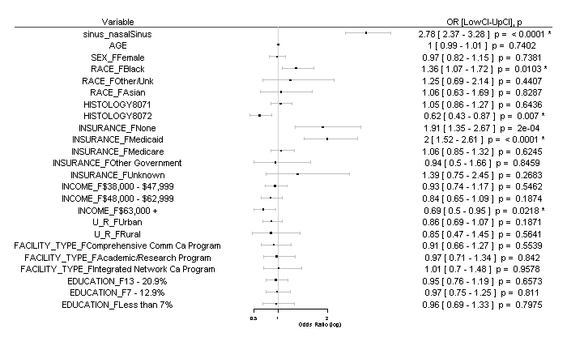

```r
fit_c_node <- glm(clin_node_pos ~ sinus_nasal + AGE + SEX_F + RACE_F + HISTOLOGY +
                          INSURANCE_F + INCOME_F + U_R_F +
                      FACILITY_TYPE_F + EDUCATION_F,
                  family = "binomial",
                  data = data_c_node)
or <- as.data.frame(exp(coefficients(fit_c_node)))
        or$Variable <- rownames(or)
        rownames(or) <- c()
        names(or) <- c('OddsRatio', 'Variable')
        ci <- as.data.frame(exp(confint(fit_c_node)))
        ci$Variable <- rownames(ci)
        rownames(ci) <- c()
        p_val_list <- tidy(fit_c_node) %>%
        select(term, p.value) %>%
        rename(Variable = term) %>%
        mutate(p.value = round(p.value, 4))
        p_val_list$p.value <- as.character(p_val_list$p.value)
        p_val_list$p.value[p_val_list$p.value == "0"] <- "< 0.0001"
        all <- full_join(or, ci, by = 'Variable')
        all <- full_join(all, p_val_list, by = "Variable")
        names(all) <- c('OddsRatio', 'Variable', 'Lower', 'Upper', "p_value")
        all <- na.omit(all)
        all <- all %>%
        filter(Variable != '(Intercept)') %>%
                mutate(Sig = case_when(p_value < 0.05 ~ "*",
                                       TRUE ~ " "))

        all <- all %>%
                mutate(final = paste(round(OddsRatio, 2), "[", round(Lower, 2),
                                     "-", round(Upper, 2), "] ",
                                     "p = ", p_value, Sig))

        text <- cbind(c("Variable", as.character(all$Variable)),
              c("OR [LowCI-UpCI], p", as.character(all$final)))
        forestplot(text,
           mean = c(NA, all$OddsRatio),
           lower = c(NA, all$Lower),
           upper = c(NA, all$Upper),
           new_page =   TRUE, zero = 1,
           clip = c(0.1, 100),
           hrzl_lines = list("2" = gpar(col="#444444")),
           vertices = TRUE,
           graph.pos = 2,
           xlab = "Odds Ratio (log)",
           align = "c",
           txt_gp = fpTxtGp(cex = 0.7),
           xticks = getTicks(low = all$Lower,
                             high = all$Upper,
                             clip=c(-Inf, Inf),
                             exp=TRUE),
           boxsize = 0.1)
```

## Pathologic nodes positive

Remove N/A and pX for pathological node model

```r
data_p_node <- data %>%
        filter(TNM_PATH_N != "N_A",
               TNM_PATH_N != "pX") %>%
        mutate(path_node_pos = case_when(TNM_PATH_N == "p0" ~ "FALSE",
                                         TRUE ~ "TRUE")) %>%
        mutate(path_node_pos = as.logical(path_node_pos)) %>%
        mutate(sinus_nasal = case_when(PRIMARY_SITE == "C300" ~ "Nasal",
                                       TRUE ~ "Sinus"))
p_table(data_p_node,
        vars = c("AGE", "SEX_F", "RACE_F", "HISTOLOGY", "INSURANCE_F",
                 "INCOME_F", "U_R_F", "FACILITY_TYPE_F", "FACILITY_TYPE_F", "EDUCATION_F"))
```

```
The data frame does not have: FACILITY_TYPE_F.1  Dropped
```

```
|                    |             level             |    Overall    |
|:-------------------|:-----------------------------:|:-------------:|
|n                   |                               |     2081      |
|AGE (mean (sd))     |                               | 64.12 (13.01) |
|SEX_F (%)           |             Male              |  1362 (65.4)  |
|                    |            Female             |  719 (34.6)   |
|RACE_F (%)          |             White             |  1780 (85.5)  |
|                    |             Black             |  201 ( 9.7)   |
|                    |           Other/Unk           |   46 ( 2.2)   |
|                    |             Asian             |   54 ( 2.6)   |
|HISTOLOGY (%)       |             8070              |  1494 (71.8)  |
|                    |             8071              |  451 (21.7)   |
|                    |             8072              |  136 ( 6.5)   |
|INSURANCE_F (%)     |            Private            |  768 (36.9)   |
|                    |             None              |   82 ( 3.9)   |
|                    |           Medicaid            |  156 ( 7.5)   |
|                    |           Medicare            |  982 (47.2)   |
|                    |       Other Government        |   51 ( 2.5)   |
|                    |            Unknown            |   42 ( 2.0)   |
|INCOME_F (%)        |       Less than $38,000       |  436 (21.0)   |
|                    |       $38,000 - $47,999       |  531 (25.5)   |
|                    |       $48,000 - $62,999       |  565 (27.2)   |
|                    |           $63,000 +           |  516 (24.8)   |
|                    |              NA               |   33 ( 1.6)   |
|U_R_F (%)           |             Metro             |  1649 (79.2)  |
|                    |             Urban             |  342 (16.4)   |
|                    |             Rural             |   31 ( 1.5)   |
|                    |              NA               |   59 ( 2.8)   |
|FACILITY_TYPE_F (%) |   Community Cancer Program    |  112 ( 5.4)   |
|                    | Comprehensive Comm Ca Program |  546 (26.2)   |
|                    |   Academic/Research Program   |  1115 (53.6)  |
|                    | Integrated Network Ca Program |  249 (12.0)   |
|                    |              NA               |   59 ( 2.8)   |
|FACILITY_TYPE_F (%) |   Community Cancer Program    |  112 ( 5.4)   |
|                    | Comprehensive Comm Ca Program |  546 (26.2)   |
|                    |   Academic/Research Program   |  1115 (53.6)  |
|                    | Integrated Network Ca Program |  249 (12.0)   |
|                    |              NA               |   59 ( 2.8)   |
```

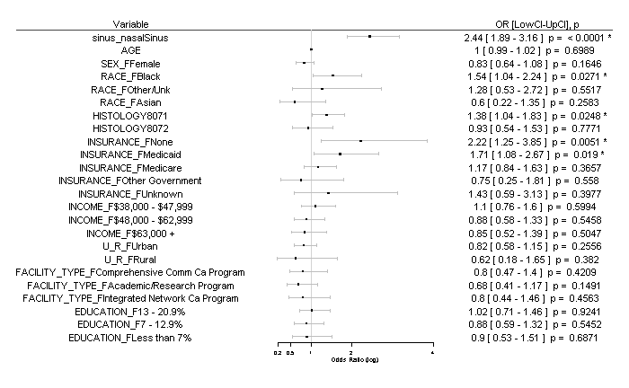

```r
fit_p_node <- glm(path_node_pos ~ sinus_nasal + AGE + SEX_F + RACE_F + HISTOLOGY +
                          INSURANCE_F + INCOME_F + U_R_F +
                      FACILITY_TYPE_F + EDUCATION_F,
                  family = "binomial",
                  data = data_p_node)
or <- as.data.frame(exp(coefficients(fit_p_node)))
        or$Variable <- rownames(or)
        rownames(or) <- c()
        names(or) <- c('OddsRatio', 'Variable')
        ci <- as.data.frame(exp(confint(fit_p_node)))
        ci$Variable <- rownames(ci)
        rownames(ci) <- c()
        p_val_list <- tidy(fit_p_node) %>%
        select(term, p.value) %>%
        rename(Variable = term) %>%
        mutate(p.value = round(p.value, 4))
        p_val_list$p.value <- as.character(p_val_list$p.value)
        p_val_list$p.value[p_val_list$p.value == "0"] <- "< 0.0001"
        all <- full_join(or, ci, by = 'Variable')
        all <- full_join(all, p_val_list, by = "Variable")
        names(all) <- c('OddsRatio', 'Variable', 'Lower', 'Upper', "p_value")
        all <- na.omit(all)
        all <- all %>%
        filter(Variable != '(Intercept)') %>%
                mutate(Sig = case_when(p_value < 0.05 ~ "*",
                                       TRUE ~ " "))

        all <- all %>%
                mutate(final = paste(round(OddsRatio, 2), "[", round(Lower, 2),
                                     "-", round(Upper, 2), "] ",
                                     "p = ", p_value, Sig))

        text <- cbind(c("Variable", as.character(all$Variable)),
              c("OR [LowCI-UpCI], p", as.character(all$final)))
        forestplot(text,
           mean = c(NA, all$OddsRatio),
           lower = c(NA, all$Lower),
           upper = c(NA, all$Upper),
           new_page =   TRUE, zero = 1,
           clip = c(0.1, 100),
           hrzl_lines = list("2" = gpar(col="#444444")),
           vertices = TRUE,
           graph.pos = 2,
           xlab = "Odds Ratio (log)",
           align = "c",
           txt_gp = fpTxtGp(cex = 0.7),
           xticks = getTicks(low = all$Lower,
                             high = all$Upper,
                             clip=c(-Inf, Inf),
                             exp=TRUE),
           boxsize = 0.1)
```

# Kaplan Meier Analysis

```r
uni_var <- function(test_var, data_imp) {

        cat("_________________________________________________")
        cat("\n")
        cat("   \n##", test_var)
        cat("\n")
        cat("_________________________________________________")
        cat("\n")

        f <- as.formula(paste("Surv(DX_LASTCONTACT_DEATH_MONTHS, PUF_VITAL_STATUS == 0)",
                              as.name(test_var),
                              sep = " ~ " ))

        data_imp_2 <- deparse(substitute(data_imp))
        km_fit <- do.call("survfit", list(formula = f, data = as.name(data_imp_2)))
        print(km_fit)
        cat("\n")
        print(summary(km_fit, times = c(12, 24, 36, 48, 60, 120)))
        cat("\n")
        cat("\n")
        cat("\n")
        cat("   \n## Univariable Cox Proportional Hazard Model for: ", test_var)
        cat("\n")
        cat("\n")
        n_levels <- nlevels(data_imp[[test_var]])
        if(n_levels == 1){
                print("Only one level, no Cox model performed")
                cat("\n")
        } else {
                cox_fit <- do.call("coxph", list(formula = f, data = as.name(data_imp_2)))
                print(summary(cox_fit))
                cat("\n")

                do.call("ggforest",
                         list(model = cox_fit, data = as.name(data_imp_2)))
        }
        cat("\n")
        cat("\n")
        cat("\n")
        cat("   \n## Unadjusted Kaplan Meier Overall Survival Curve for: ", test_var)
        p <- do.call("ggsurvplot",
                     list(fit = km_fit, data = as.name(data_imp_2),
                          palette = "jco", censor = FALSE, legend = "right",
                          linetype = "strata", xlab = "Time (Months)"))
        print(p)
}
```

## All

```r
uni_var(test_var = "All", data_imp = data)
```

[output not shown]

```
_________________________________________________

## All
_________________________________________________
Call: survfit(formula = Surv(DX_LASTCONTACT_DEATH_MONTHS, PUF_VITAL_STATUS ==
    0) ~ All, data = data)

      n  events  median 0.95LCL 0.95UCL
 6448.0  3319.0    58.0    54.3    63.4

Call: survfit(formula = Surv(DX_LASTCONTACT_DEATH_MONTHS, PUF_VITAL_STATUS ==
    0) ~ All, data = data)

 time n.risk n.event survival std.err lower 95% CI upper 95% CI
   12   4961    1311    0.794 0.00508        0.784        0.804
   24   3831     790    0.663 0.00600        0.652        0.675
   36   2977     417    0.587 0.00637        0.575        0.600
   48   2326     242    0.536 0.00661        0.524        0.549
   60   1822     163    0.496 0.00683        0.483        0.509
  120    271     367    0.334 0.00918        0.317        0.353




## Univariable Cox Proportional Hazard Model for:  All

[1] "Only one level, no Cox model performed"





## Unadjusted Kaplan Meier Overall Survival Curve for:  All
```

## Facility Type

```
_________________________________________________

## FACILITY_TYPE_F
_________________________________________________
Call: survfit(formula = Surv(DX_LASTCONTACT_DEATH_MONTHS, PUF_VITAL_STATUS ==
    0) ~ FACILITY_TYPE_F, data = data)

   164 observations deleted due to missingness
                                                 n events median 0.95LCL 0.95UCL
FACILITY_TYPE_F=Community Cancer Program       453    252   39.1    33.3    54.7
FACILITY_TYPE_F=Comprehensive Comm Ca Program 2010   1113   50.7    46.3    59.6
FACILITY_TYPE_F=Academic/Research Program     3107   1542   63.9    57.9    70.1
FACILITY_TYPE_F=Integrated Network Ca Program  714    351   56.2    50.2    79.9

Call: survfit(formula = Surv(DX_LASTCONTACT_DEATH_MONTHS, PUF_VITAL_STATUS ==
    0) ~ FACILITY_TYPE_F, data = data)

164 observations deleted due to missingness
                FACILITY_TYPE_F=Community Cancer Program
 time n.risk n.event survival std.err lower 95% CI upper 95% CI
   12    325     110    0.751  0.0206        0.712        0.793
   24    242      62    0.603  0.0236        0.559        0.651
   36    180      31    0.520  0.0246        0.474        0.571
   48    147      17    0.469  0.0252        0.422        0.521
   60    115       9    0.438  0.0255        0.391        0.491
  120     16      21    0.303  0.0335        0.244        0.376

                FACILITY_TYPE_F=Comprehensive Comm Ca Program
 time n.risk n.event survival std.err lower 95% CI upper 95% CI
   12   1500     459    0.768 0.00949        0.750        0.787
   24   1184     232    0.646 0.01085        0.626        0.668
   36    908     139    0.567 0.01143        0.545        0.590
   48    715      80    0.514 0.01181        0.491        0.537
   60    574      50    0.476 0.01210        0.453        0.500
  120     89     141    0.306 0.01490        0.278        0.337

                FACILITY_TYPE_F=Academic/Research Program
 time n.risk n.event survival std.err lower 95% CI upper 95% CI
   12   2454     577    0.812 0.00706        0.798        0.826
   24   1860     400    0.675 0.00857        0.658        0.692
```

[output cut: 29 more lines]

```
FACILITY_TYPE_FAcademic/Research Program     -0.20446   0.81509  0.06795 -3.009  0.00262 **
FACILITY_TYPE_FIntegrated Network Ca Program -0.20829   0.81197  0.08257 -2.522  0.01165 *
---
Signif. codes:  0 *** 0.001 ** 0.01 * 0.05 . 0.1   1

                                             exp(coef) exp(-coef) lower .95 upper .95
FACILITY_TYPE_FComprehensive Comm Ca Program    0.9313      1.074    0.8123    1.0678
FACILITY_TYPE_FAcademic/Research Program        0.8151      1.227    0.7135    0.9312
FACILITY_TYPE_FIntegrated Network Ca Program    0.8120      1.232    0.6906    0.9546

Concordance= 0.519  (se = 0.005 )
Rsquare= 0.003   (max possible= 1 )
Likelihood ratio test= 17.96  on 3 df,   p=0.0004473
Wald test            = 18.22  on 3 df,   p=0.0003968
Score (logrank) test = 18.26  on 3 df,   p=0.0003895
```

```
Removed 1 rows containing missing values (geom_errorbar).
```

```
## Unadjusted Kaplan Meier Overall Survival Curve for:  FACILITY_TYPE_F
```

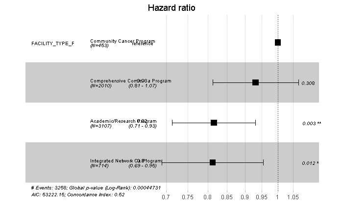

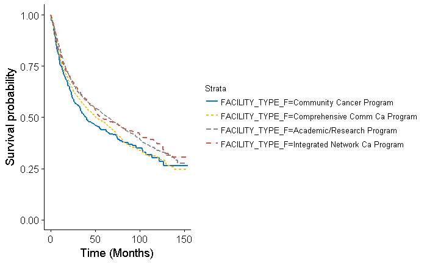

```r
uni_var(test_var = "FACILITY_TYPE_F", data_imp = data)
```

## Facility Location

```
_________________________________________________

## FACILITY_LOCATION_F
_________________________________________________
Call: survfit(formula = Surv(DX_LASTCONTACT_DEATH_MONTHS, PUF_VITAL_STATUS ==
    0) ~ FACILITY_LOCATION_F, data = data)

   164 observations deleted due to missingness
                                          n events median 0.95LCL 0.95UCL
FACILITY_LOCATION_F=New England         299    156   55.5    41.6    73.3
FACILITY_LOCATION_F=Middle Atlantic     871    429   59.8    49.6    74.2
FACILITY_LOCATION_F=South Atlantic     1564    819   53.2    47.2    62.7
FACILITY_LOCATION_F=East North Central 1076    553   62.6    51.1    79.5
FACILITY_LOCATION_F=East South Central  579    321   52.5    41.9    66.9
FACILITY_LOCATION_F=West North Central  477    259   56.5    42.3    67.4
FACILITY_LOCATION_F=West South Central  465    236   62.0    42.7    82.2
FACILITY_LOCATION_F=Mountain            260    135   63.4    45.0    81.7
FACILITY_LOCATION_F=Pacific             693    350   64.3    50.8    75.1

Call: survfit(formula = Surv(DX_LASTCONTACT_DEATH_MONTHS, PUF_VITAL_STATUS ==
    0) ~ FACILITY_LOCATION_F, data = data)

164 observations deleted due to missingness
                FACILITY_LOCATION_F=New England
 time n.risk n.event survival std.err lower 95% CI upper 95% CI
   12    232      60    0.797  0.0234        0.753        0.844
   24    176      36    0.669  0.0277        0.617        0.726
   36    134      19    0.592  0.0297        0.537        0.653
   48    104      14    0.525  0.0313        0.467        0.590
   60     81       9    0.475  0.0325        0.415        0.543
  120     12      17    0.340  0.0373        0.275        0.422

                FACILITY_LOCATION_F=Middle Atlantic
 time n.risk n.event survival std.err lower 95% CI upper 95% CI
   12    675     169    0.803  0.0136        0.776        0.830
   24    514     108    0.669  0.0163        0.638        0.702
   36    381      61    0.584  0.0175        0.551        0.620
   48    296      27    0.540  0.0182        0.505        0.576
   60    225      20    0.500  0.0189        0.464        0.538
  120     24      43    0.317  0.0279        0.267        0.377
```

[output cut: 87 more lines]

```
                                      exp(coef) exp(-coef) lower .95 upper .95
FACILITY_LOCATION_FMiddle Atlantic       0.9636     1.0378    0.8023     1.157
FACILITY_LOCATION_FSouth Atlantic        1.0133     0.9869    0.8538     1.203
FACILITY_LOCATION_FEast North Central    0.9436     1.0598    0.7899     1.127
FACILITY_LOCATION_FEast South Central    1.0607     0.9428    0.8760     1.284
FACILITY_LOCATION_FWest North Central    1.0136     0.9866    0.8310     1.236
FACILITY_LOCATION_FWest South Central    0.9951     1.0049    0.8129     1.218
FACILITY_LOCATION_FMountain              0.9582     1.0436    0.7610     1.206
FACILITY_LOCATION_FPacific               0.9672     1.0339    0.8009     1.168

Concordance= 0.508  (se = 0.005 )
Rsquare= 0.001   (max possible= 1 )
Likelihood ratio test= 4.04  on 8 df,   p=0.8532
Wald test            = 4.06  on 8 df,   p=0.8519
Score (logrank) test = 4.06  on 8 df,   p=0.8517
```

```
Removed 1 rows containing missing values (geom_errorbar).
```

```
## Unadjusted Kaplan Meier Overall Survival Curve for:  FACILITY_LOCATION_F
```

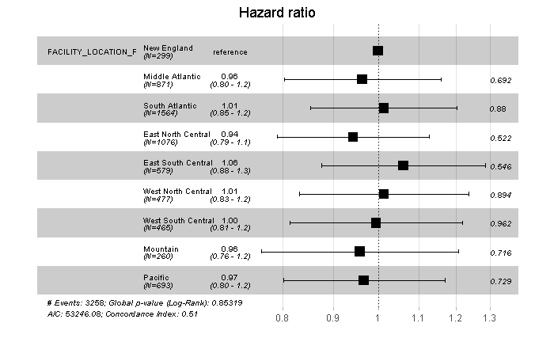

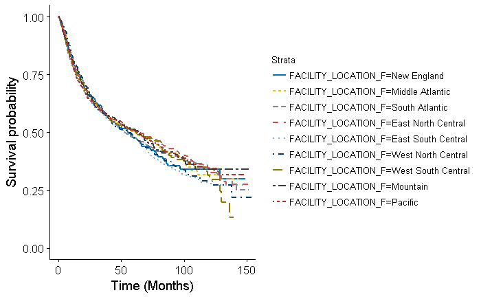

```r
uni_var(test_var = "FACILITY_LOCATION_F", data_imp = data)
```

## Facility Geography

```
_________________________________________________

## FACILITY_GEOGRAPHY
_________________________________________________
Call: survfit(formula = Surv(DX_LASTCONTACT_DEATH_MONTHS, PUF_VITAL_STATUS ==
    0) ~ FACILITY_GEOGRAPHY, data = data)

   164 observations deleted due to missingness
                                n events median 0.95LCL 0.95UCL
FACILITY_GEOGRAPHY=Northeast 1170    585   58.9    49.7    72.6
FACILITY_GEOGRAPHY=South     2029   1055   54.4    48.8    62.9
FACILITY_GEOGRAPHY=Midwest   2132   1133   57.4    50.2    66.0
FACILITY_GEOGRAPHY=West       953    485   63.9    52.4    71.6

Call: survfit(formula = Surv(DX_LASTCONTACT_DEATH_MONTHS, PUF_VITAL_STATUS ==
    0) ~ FACILITY_GEOGRAPHY, data = data)

164 observations deleted due to missingness
                FACILITY_GEOGRAPHY=Northeast
 time n.risk n.event survival std.err lower 95% CI upper 95% CI
   12    907     229    0.801  0.0118        0.779        0.825
   24    690     144    0.669  0.0141        0.642        0.697
   36    515      80    0.586  0.0151        0.557        0.617
   48    400      41    0.536  0.0157        0.506        0.568
   60    306      29    0.493  0.0164        0.462        0.526
  120     36      60    0.325  0.0226        0.284        0.373

                FACILITY_GEOGRAPHY=South
 time n.risk n.event survival std.err lower 95% CI upper 95% CI
   12   1512     453    0.773 0.00939        0.755        0.791
   24   1187     232    0.651 0.01080        0.630        0.672
   36    931     119    0.582 0.01135        0.560        0.605
   48    715      83    0.526 0.01181        0.504        0.550
   60    559      53    0.484 0.01221        0.461        0.509
  120     82     101    0.341 0.01647        0.310        0.375

                FACILITY_GEOGRAPHY=Midwest
 time n.risk n.event survival std.err lower 95% CI upper 95% CI
   12   1671     415    0.803 0.00868        0.786        0.820
   24   1286     267    0.670 0.01037        0.650        0.691
```

[output cut: 27 more lines]

```
                               coef exp(coef)  se(coef)      z Pr(>|z|)
FACILITY_GEOGRAPHYSouth    0.036497  1.037171  0.051559  0.708    0.479
FACILITY_GEOGRAPHYMidwest  0.017477  1.017631  0.050928  0.343    0.731
FACILITY_GEOGRAPHYWest    -0.008605  0.991432  0.061425 -0.140    0.889

                          exp(coef) exp(-coef) lower .95 upper .95
FACILITY_GEOGRAPHYSouth      1.0372     0.9642    0.9375     1.147
FACILITY_GEOGRAPHYMidwest    1.0176     0.9827    0.9210     1.124
FACILITY_GEOGRAPHYWest       0.9914     1.0086    0.8790     1.118

Concordance= 0.506  (se = 0.005 )
Rsquare= 0   (max possible= 1 )
Likelihood ratio test= 0.89  on 3 df,   p=0.8282
Wald test            = 0.89  on 3 df,   p=0.8284
Score (logrank) test = 0.89  on 3 df,   p=0.8284
```

```
Removed 1 rows containing missing values (geom_errorbar).
```

```
## Unadjusted Kaplan Meier Overall Survival Curve for:  FACILITY_GEOGRAPHY
```

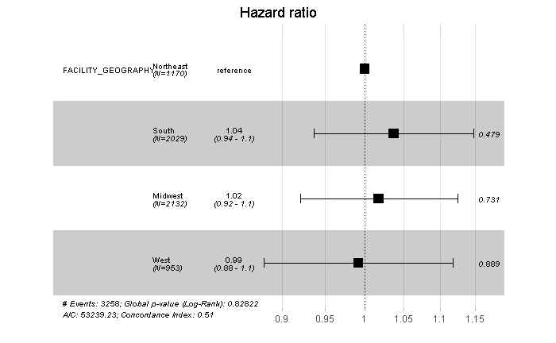

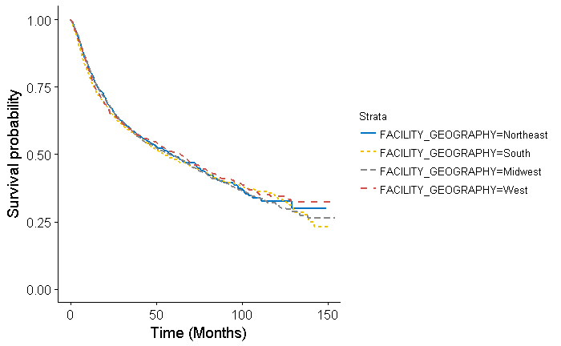

```r
uni_var(test_var = "FACILITY_GEOGRAPHY", data_imp = data)
```

## Age Group

```
_________________________________________________

## AGE_F
_________________________________________________
Call: survfit(formula = Surv(DX_LASTCONTACT_DEATH_MONTHS, PUF_VITAL_STATUS ==
    0) ~ AGE_F, data = data)

                  n events median 0.95LCL 0.95UCL
AGE_F=(0,54]   1402    525  129.1   109.8      NA
AGE_F=(54,64]  1601    695   87.2    76.9     102
AGE_F=(64,74]  1699    853   63.5    56.2      70
AGE_F=(74,100] 1746   1246   25.3    22.7      28

Call: survfit(formula = Surv(DX_LASTCONTACT_DEATH_MONTHS, PUF_VITAL_STATUS ==
    0) ~ AGE_F, data = data)

                AGE_F=(0,54]
 time n.risk n.event survival std.err lower 95% CI upper 95% CI
   12   1177     180    0.869  0.0091        0.851        0.887
   24    950     147    0.757  0.0117        0.735        0.781
   36    763      86    0.686  0.0129        0.661        0.712
   48    604      40    0.648  0.0135        0.622        0.675
   60    485      28    0.615  0.0142        0.588        0.644
  120     93      39    0.527  0.0188        0.492        0.565

                AGE_F=(54,64]
 time n.risk n.event survival std.err lower 95% CI upper 95% CI
   12   1306     251    0.841 0.00922        0.823        0.859
   24   1031     183    0.719 0.01146        0.697        0.742
   36    820      85    0.657 0.01232        0.633        0.681
   48    658      51    0.613 0.01294        0.588        0.639
   60    524      38    0.575 0.01353        0.549        0.602
  120     84      80    0.435 0.01812        0.401        0.472

                AGE_F=(64,74]
 time n.risk n.event survival std.err lower 95% CI upper 95% CI
   12   1346     309    0.816 0.00948        0.797        0.834
   24   1048     203    0.689 0.01146        0.667        0.711
   36    815     110    0.612 0.01229        0.589        0.637
   48    639      75    0.552 0.01290        0.528        0.578
```

[output cut: 26 more lines]

```
AGE_F(64,74]  0.39095   1.47838  0.05549  7.045 1.86e-12 ***
AGE_F(74,100] 1.00541   2.73303  0.05223 19.249  < 2e-16 ***
---
Signif. codes:  0 *** 0.001 ** 0.01 * 0.05 . 0.1   1

              exp(coef) exp(-coef) lower .95 upper .95
AGE_F(54,64]      1.201     0.8323     1.073     1.346
AGE_F(64,74]      1.478     0.6764     1.326     1.648
AGE_F(74,100]     2.733     0.3659     2.467     3.028

Concordance= 0.598  (se = 0.005 )
Rsquare= 0.074   (max possible= 1 )
Likelihood ratio test= 498.1  on 3 df,   p=0
Wald test            = 522.2  on 3 df,   p=0
Score (logrank) test = 552.7  on 3 df,   p=0
```

```
Removed 1 rows containing missing values (geom_errorbar).
```

```
## Unadjusted Kaplan Meier Overall Survival Curve for:  AGE_F
```

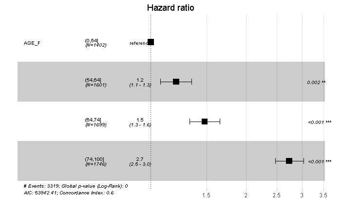

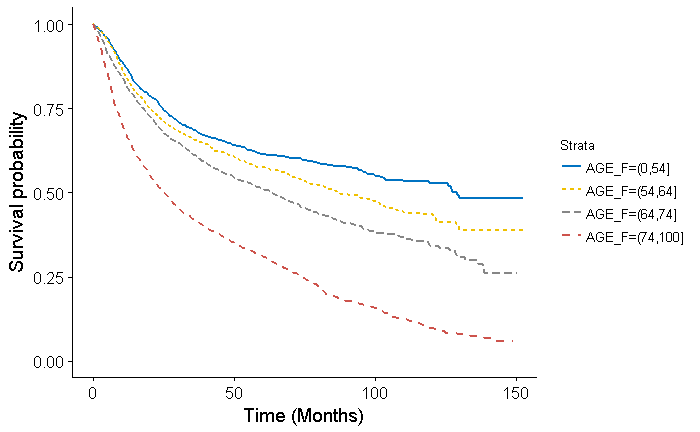

```r
uni_var(test_var = "AGE_F", data_imp = data)
```

## Age Group

```
_________________________________________________

## AGE_40
_________________________________________________
Call: survfit(formula = Surv(DX_LASTCONTACT_DEATH_MONTHS, PUF_VITAL_STATUS ==
    0) ~ AGE_40, data = data)

                   n events median 0.95LCL 0.95UCL
AGE_40=(0,40]    195     68     NA   119.3      NA
AGE_40=(40,100] 6253   3251   57.3    52.8    62.5

Call: survfit(formula = Surv(DX_LASTCONTACT_DEATH_MONTHS, PUF_VITAL_STATUS ==
    0) ~ AGE_40, data = data)

                AGE_40=(0,40]
 time n.risk n.event survival std.err lower 95% CI upper 95% CI
   12    165      24    0.874  0.0240        0.828        0.923
   24    135      21    0.761  0.0312        0.702        0.824
   36    111      11    0.696  0.0341        0.633        0.766
   48     90       5    0.664  0.0355        0.598        0.737
   60     73       4    0.633  0.0370        0.564        0.710
  120     13       3    0.570  0.0552        0.472        0.689

                AGE_40=(40,100]
 time n.risk n.event survival std.err lower 95% CI upper 95% CI
   12   4796    1287    0.791 0.00518        0.781        0.801
   24   3696     769    0.660 0.00611        0.648        0.672
   36   2866     406    0.584 0.00648        0.571        0.597
   48   2236     237    0.532 0.00672        0.519        0.546
   60   1749     159    0.492 0.00694        0.478        0.505
  120    258     364    0.327 0.00927        0.309        0.346





## Univariable Cox Proportional Hazard Model for:  AGE_40

Call:
coxph(formula = Surv(DX_LASTCONTACT_DEATH_MONTHS, PUF_VITAL_STATUS ==
    0) ~ AGE_40, data = data)

  n= 6448, number of events= 3319

                 coef exp(coef) se(coef)     z Pr(>|z|)
AGE_40(40,100] 0.5577    1.7466   0.1225 4.551 5.35e-06 ***
---
Signif. codes:  0 *** 0.001 ** 0.01 * 0.05 . 0.1   1

               exp(coef) exp(-coef) lower .95 upper .95
AGE_40(40,100]     1.747     0.5725     1.374     2.221

Concordance= 0.506  (se = 0.002 )
Rsquare= 0.004   (max possible= 1 )
Likelihood ratio test= 24.91  on 1 df,   p=5.994e-07
Wald test            = 20.71  on 1 df,   p=5.35e-06
Score (logrank) test = 21.25  on 1 df,   p=4.031e-06
```

```
Removed 1 rows containing missing values (geom_errorbar).
```

```
## Unadjusted Kaplan Meier Overall Survival Curve for:  AGE_40
```

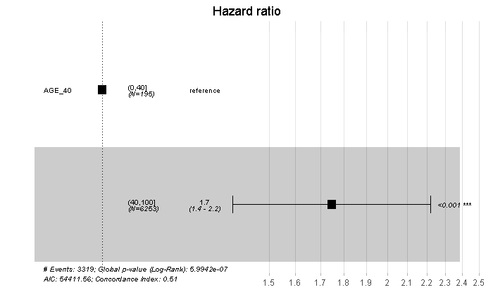

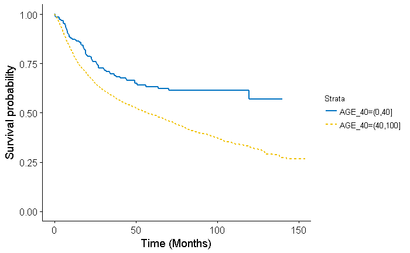

```r
uni_var(test_var = "AGE_40", data_imp = data)
```

## Gender

```
_________________________________________________

## SEX_F
_________________________________________________
Call: survfit(formula = Surv(DX_LASTCONTACT_DEATH_MONTHS, PUF_VITAL_STATUS ==
    0) ~ SEX_F, data = data)

                n events median 0.95LCL 0.95UCL
SEX_F=Male   4135   2130   57.4    51.8    63.9
SEX_F=Female 2313   1189   59.6    53.4    66.3

Call: survfit(formula = Surv(DX_LASTCONTACT_DEATH_MONTHS, PUF_VITAL_STATUS ==
    0) ~ SEX_F, data = data)

                SEX_F=Male
 time n.risk n.event survival std.err lower 95% CI upper 95% CI
   12   3211     807    0.802 0.00626        0.789        0.814
   24   2459     516    0.668 0.00748        0.654        0.683
   36   1900     285    0.587 0.00798        0.572        0.603
   48   1489     159    0.535 0.00828        0.519        0.551
   60   1180     107    0.494 0.00855        0.477        0.511
  120    174     240    0.328 0.01154        0.306        0.351

                SEX_F=Female
 time n.risk n.event survival std.err lower 95% CI upper 95% CI
   12   1750     504    0.779 0.00869        0.762        0.796
   24   1372     274    0.654 0.01005        0.635        0.674
   36   1077     132    0.588 0.01058        0.567        0.609
   48    837      83    0.539 0.01098        0.518        0.561
   60    642      56    0.500 0.01137        0.478        0.522
  120     97     127    0.346 0.01506        0.318        0.377





## Univariable Cox Proportional Hazard Model for:  SEX_F

Call:
coxph(formula = Surv(DX_LASTCONTACT_DEATH_MONTHS, PUF_VITAL_STATUS ==
    0) ~ SEX_F, data = data)

  n= 6448, number of events= 3319

                coef exp(coef) se(coef)     z Pr(>|z|)
SEX_FFemale 0.007766  1.007797 0.036202 0.215     0.83

            exp(coef) exp(-coef) lower .95 upper .95
SEX_FFemale     1.008     0.9923    0.9388     1.082

Concordance= 0.505  (se = 0.004 )
Rsquare= 0   (max possible= 1 )
Likelihood ratio test= 0.05  on 1 df,   p=0.8302
Wald test            = 0.05  on 1 df,   p=0.8301
Score (logrank) test = 0.05  on 1 df,   p=0.8301
```

```
Removed 1 rows containing missing values (geom_errorbar).
```

```
## Unadjusted Kaplan Meier Overall Survival Curve for:  SEX_F
```

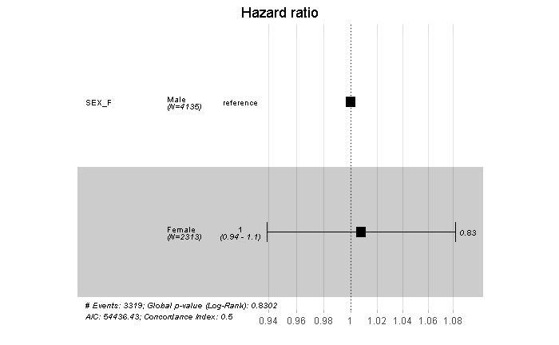

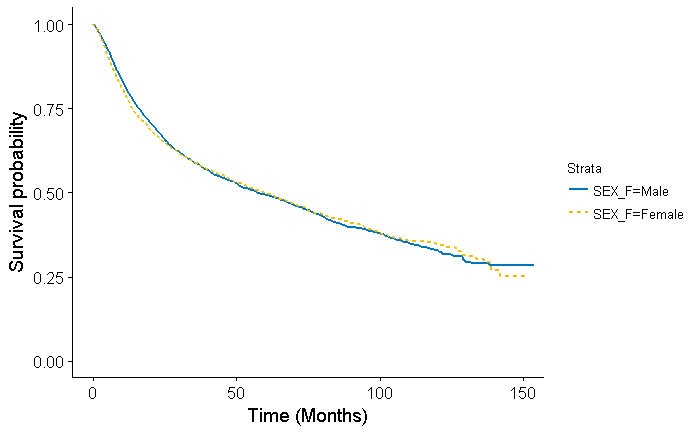

```r
uni_var(test_var = "SEX_F", data_imp = data)
```

## RACE_F

```
_________________________________________________

## RACE_F
_________________________________________________
Call: survfit(formula = Surv(DX_LASTCONTACT_DEATH_MONTHS, PUF_VITAL_STATUS ==
    0) ~ RACE_F, data = data)

                    n events median 0.95LCL 0.95UCL
RACE_F=White     5506   2788   62.5    57.3    67.3
RACE_F=Black      647    385   32.7    26.3    41.4
RACE_F=Other/Unk  134     60   95.3    64.3      NA
RACE_F=Asian      161     86   46.1    26.7    94.0

Call: survfit(formula = Surv(DX_LASTCONTACT_DEATH_MONTHS, PUF_VITAL_STATUS ==
    0) ~ RACE_F, data = data)

                RACE_F=White
 time n.risk n.event survival std.err lower 95% CI upper 95% CI
   12   4262    1091    0.799 0.00545        0.788        0.810
   24   3327     633    0.676 0.00643        0.664        0.689
   36   2600     357    0.600 0.00686        0.587        0.614
   48   2036     215    0.547 0.00715        0.533        0.561
   60   1592     142    0.506 0.00740        0.492        0.521
  120    227     323    0.339 0.01004        0.320        0.360

                RACE_F=Black
 time n.risk n.event survival std.err lower 95% CI upper 95% CI
   12    464     168    0.737  0.0175        0.703        0.772
   24    333     106    0.564  0.0199        0.526        0.604
   36    244      45    0.483  0.0204        0.444        0.524
   48    177      21    0.437  0.0207        0.399        0.480
   60    143      15    0.399  0.0211        0.360        0.443
  120     25      28    0.284  0.0250        0.239        0.337

                RACE_F=Other/Unk
 time n.risk n.event survival std.err lower 95% CI upper 95% CI
   12    110      19    0.854  0.0311        0.795        0.917
   24     81      22    0.680  0.0413        0.604        0.766
   36     66       3    0.653  0.0425        0.575        0.742
   48     60       2    0.633  0.0435        0.554        0.724
```

[output cut: 26 more lines]

```
RACE_FOther/Unk -0.20126   0.81770  0.13051 -1.542    0.123
RACE_FAsian      0.08766   1.09161  0.10949  0.801    0.423
---
Signif. codes:  0 *** 0.001 ** 0.01 * 0.05 . 0.1   1

                exp(coef) exp(-coef) lower .95 upper .95
RACE_FBlack        1.3272     0.7534    1.1930     1.477
RACE_FOther/Unk    0.8177     1.2229    0.6331     1.056
RACE_FAsian        1.0916     0.9161    0.8808     1.353

Concordance= 0.518  (se = 0.003 )
Rsquare= 0.004   (max possible= 1 )
Likelihood ratio test= 28.94  on 3 df,   p=2.309e-06
Wald test            = 30.63  on 3 df,   p=1.019e-06
Score (logrank) test = 30.84  on 3 df,   p=9.184e-07
```

```
Removed 1 rows containing missing values (geom_errorbar).
```

```
## Unadjusted Kaplan Meier Overall Survival Curve for:  RACE_F
```

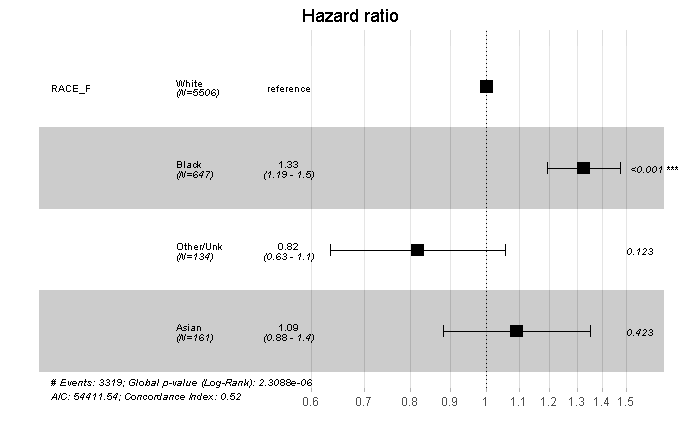

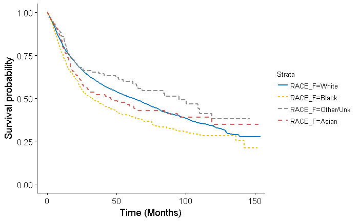

```r
uni_var(test_var = "RACE_F", data_imp = data)
```

## Hispanic

```
_________________________________________________

## HISPANIC
_________________________________________________
Call: survfit(formula = Surv(DX_LASTCONTACT_DEATH_MONTHS, PUF_VITAL_STATUS ==
    0) ~ HISPANIC, data = data)

                    n events median 0.95LCL 0.95UCL
HISPANIC=No      5726   2943   58.5    54.0    63.6
HISPANIC=Yes      343    162   55.9    46.6   108.1
HISPANIC=Unknown  379    214   56.5    43.0    70.9

Call: survfit(formula = Surv(DX_LASTCONTACT_DEATH_MONTHS, PUF_VITAL_STATUS ==
    0) ~ HISPANIC, data = data)

                HISPANIC=No
 time n.risk n.event survival std.err lower 95% CI upper 95% CI
   12   4426    1154    0.796 0.00537        0.785        0.806
   24   3421     706    0.665 0.00636        0.653        0.677
   36   2646     378    0.587 0.00676        0.574        0.601
   48   2060     216    0.536 0.00701        0.523        0.550
   60   1620     140    0.497 0.00724        0.483        0.511
  120    236     324    0.336 0.00979        0.317        0.356

                HISPANIC=Yes
 time n.risk n.event survival std.err lower 95% CI upper 95% CI
   12    245      79    0.763  0.0233        0.719        0.810
   24    179      40    0.633  0.0269        0.583        0.688
   36    143      16    0.575  0.0282        0.522        0.633
   48    112       9    0.535  0.0292        0.481        0.596
   60     80       7    0.498  0.0304        0.442        0.561
  120     11      10    0.377  0.0444        0.299        0.474

                HISPANIC=Unknown
 time n.risk n.event survival std.err lower 95% CI upper 95% CI
   12    290      78    0.789  0.0212        0.749        0.832
   24    231      44    0.667  0.0247        0.620        0.717
   36    188      23    0.597  0.0260        0.548        0.650
   48    154      17    0.541  0.0269        0.491        0.597
   60    122      16    0.482  0.0277        0.431        0.540
```

[output cut: 12 more lines]

```
  n= 6448, number of events= 3319

                     coef exp(coef)  se(coef)     z Pr(>|z|)
HISPANICYes     0.0002073 1.0002073 0.0807051 0.003    0.998
HISPANICUnknown 0.0436779 1.0446459 0.0708249 0.617    0.537

                exp(coef) exp(-coef) lower .95 upper .95
HISPANICYes         1.000     0.9998    0.8539     1.172
HISPANICUnknown     1.045     0.9573    0.9092     1.200

Concordance= 0.502  (se = 0.003 )
Rsquare= 0   (max possible= 1 )
Likelihood ratio test= 0.38  on 2 df,   p=0.8283
Wald test            = 0.38  on 2 df,   p=0.8263
Score (logrank) test = 0.38  on 2 df,   p=0.8263
```

```
Removed 1 rows containing missing values (geom_errorbar).
```

```
## Unadjusted Kaplan Meier Overall Survival Curve for:  HISPANIC
```

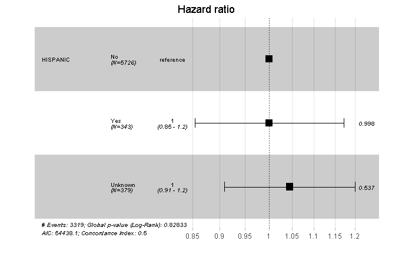

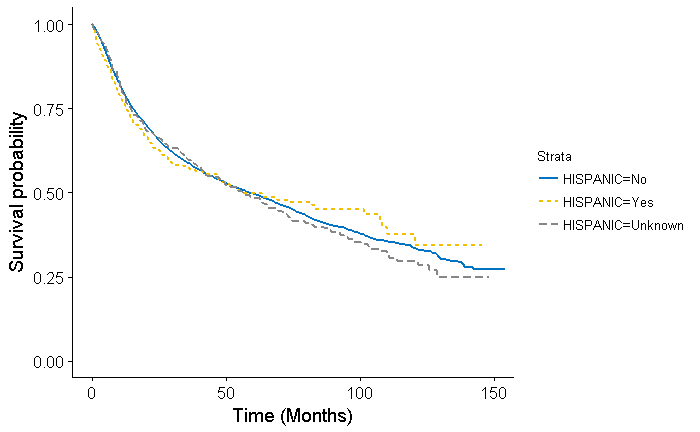

```r
uni_var(test_var = "HISPANIC", data_imp = data)
```

## Insurance Status

```
_________________________________________________

## INSURANCE_F
_________________________________________________
Call: survfit(formula = Surv(DX_LASTCONTACT_DEATH_MONTHS, PUF_VITAL_STATUS ==
    0) ~ INSURANCE_F, data = data)

                                n events median 0.95LCL 0.95UCL
INSURANCE_F=Private          2151    829  119.3   101.4      NA
INSURANCE_F=None              281    145   55.5    35.8    80.4
INSURANCE_F=Medicaid          512    271   41.6    29.6    56.1
INSURANCE_F=Medicare         3250   1952   39.8    37.2    43.7
INSURANCE_F=Other Government  126     51   91.9    86.5      NA
INSURANCE_F=Unknown           128     71   63.4    28.1    98.2

Call: survfit(formula = Surv(DX_LASTCONTACT_DEATH_MONTHS, PUF_VITAL_STATUS ==
    0) ~ INSURANCE_F, data = data)

                INSURANCE_F=Private
 time n.risk n.event survival std.err lower 95% CI upper 95% CI
   12   1800     289    0.863 0.00748        0.849        0.878
   24   1481     201    0.764 0.00934        0.746        0.782
   36   1190     126    0.696 0.01030        0.676        0.716
   48    975      61    0.658 0.01083        0.637        0.679
   60    790      49    0.622 0.01136        0.601        0.645
  120    143      96    0.497 0.01542        0.468        0.529

                INSURANCE_F=None
 time n.risk n.event survival std.err lower 95% CI upper 95% CI
   12    216      54    0.803  0.0240        0.758        0.852
   24    153      48    0.620  0.0297        0.565        0.681
   36    123      15    0.557  0.0309        0.499        0.621
   48     94       9    0.513  0.0318        0.454        0.579
   60     70       7    0.469  0.0332        0.408        0.538
  120      7      11    0.328  0.0480        0.246        0.437

                INSURANCE_F=Medicaid
 time n.risk n.event survival std.err lower 95% CI upper 95% CI
   12    359     131    0.739  0.0197        0.701        0.778
   24    256      75    0.579  0.0225        0.537        0.625
```

[output cut: 50 more lines]

```
---
Signif. codes:  0 *** 0.001 ** 0.01 * 0.05 . 0.1   1

                            exp(coef) exp(-coef) lower .95 upper .95
INSURANCE_FNone                 1.605     0.6229    1.3455     1.915
INSURANCE_FMedicaid             1.827     0.5473    1.5927     2.096
INSURANCE_FMedicare             1.952     0.5122    1.7997     2.118
INSURANCE_FOther Government     1.067     0.9369    0.8044     1.416
INSURANCE_FUnknown              1.593     0.6276    1.2504     2.030

Concordance= 0.571  (se = 0.005 )
Rsquare= 0.045   (max possible= 1 )
Likelihood ratio test= 294.8  on 5 df,   p=0
Wald test            = 272  on 5 df,   p=0
Score (logrank) test = 281.4  on 5 df,   p=0
```

```
Removed 1 rows containing missing values (geom_errorbar).
```

```
## Unadjusted Kaplan Meier Overall Survival Curve for:  INSURANCE_F
```

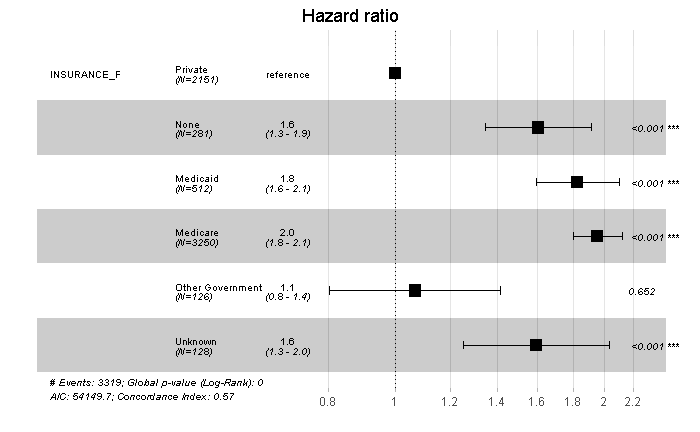

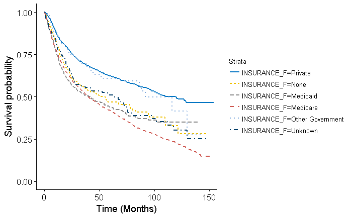

```r
uni_var(test_var = "INSURANCE_F", data_imp = data)
```

## Income

```
_________________________________________________

## INCOME_F
_________________________________________________
Call: survfit(formula = Surv(DX_LASTCONTACT_DEATH_MONTHS, PUF_VITAL_STATUS ==
    0) ~ INCOME_F, data = data)

   87 observations deleted due to missingness
                              n events median 0.95LCL 0.95UCL
INCOME_F=Less than $38,000 1348    747   46.2    38.3    54.3
INCOME_F=$38,000 - $47,999 1649    876   56.0    50.4    66.1
INCOME_F=$48,000 - $62,999 1711    879   61.4    51.1    68.6
INCOME_F=$63,000 +         1653    759   75.2    65.4    83.8

Call: survfit(formula = Surv(DX_LASTCONTACT_DEATH_MONTHS, PUF_VITAL_STATUS ==
    0) ~ INCOME_F, data = data)

87 observations deleted due to missingness
                INCOME_F=Less than $38,000
 time n.risk n.event survival std.err lower 95% CI upper 95% CI
   12   1020     290    0.781  0.0114        0.759        0.804
   24    763     193    0.629  0.0134        0.603        0.656
   36    572     101    0.541  0.0141        0.514        0.569
   48    438      46    0.494  0.0145        0.467        0.523
   60    335      33    0.454  0.0149        0.425        0.484
  120     51      76    0.281  0.0205        0.244        0.325

                INCOME_F=$38,000 - $47,999
 time n.risk n.event survival std.err lower 95% CI upper 95% CI
   12   1259     354    0.783  0.0102        0.763        0.803
   24    982     191    0.660  0.0119        0.637        0.684
   36    779     105    0.586  0.0125        0.562        0.611
   48    606      63    0.535  0.0130        0.511        0.562
   60    471      52    0.486  0.0135        0.460        0.513
  120     76     103    0.328  0.0169        0.297        0.363

                INCOME_F=$48,000 - $62,999
 time n.risk n.event survival std.err lower 95% CI upper 95% CI
   12   1308     358    0.788 0.00996        0.769        0.808
   24   1012     206    0.660 0.01167        0.638        0.683
```

[output cut: 29 more lines]

```
INCOME_F$48,000 - $62,999 -0.12471   0.88275  0.04977 -2.506   0.0122 *
INCOME_F$63,000 +         -0.27924   0.75636  0.05155 -5.417 6.07e-08 ***
---
Signif. codes:  0 *** 0.001 ** 0.01 * 0.05 . 0.1   1

                          exp(coef) exp(-coef) lower .95 upper .95
INCOME_F$38,000 - $47,999    0.9016      1.109    0.8177    0.9940
INCOME_F$48,000 - $62,999    0.8828      1.133    0.8007    0.9732
INCOME_F$63,000 +            0.7564      1.322    0.6837    0.8368

Concordance= 0.525  (se = 0.005 )
Rsquare= 0.005   (max possible= 1 )
Likelihood ratio test= 30.49  on 3 df,   p=1.091e-06
Wald test            = 30.11  on 3 df,   p=1.309e-06
Score (logrank) test = 30.23  on 3 df,   p=1.235e-06
```

```
Removed 1 rows containing missing values (geom_errorbar).
```

```
## Unadjusted Kaplan Meier Overall Survival Curve for:  INCOME_F
```

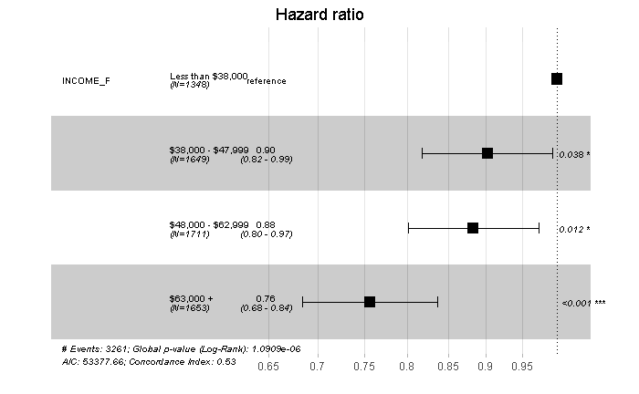

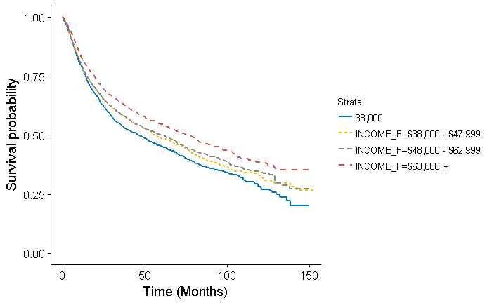

```r
uni_var(test_var = "INCOME_F", data_imp = data)
```

## Education

```
_________________________________________________

## EDUCATION_F
_________________________________________________
Call: survfit(formula = Surv(DX_LASTCONTACT_DEATH_MONTHS, PUF_VITAL_STATUS ==
    0) ~ EDUCATION_F, data = data)

   83 observations deleted due to missingness
                            n events median 0.95LCL 0.95UCL
EDUCATION_F=21% or more  1268    670   52.4    41.9    63.9
EDUCATION_F=13 - 20.9%   1817    965   54.7    50.2    62.3
EDUCATION_F=7 - 12.9%    2039   1032   63.4    54.0    71.5
EDUCATION_F=Less than 7% 1241    595   68.9    60.0    80.3

Call: survfit(formula = Surv(DX_LASTCONTACT_DEATH_MONTHS, PUF_VITAL_STATUS ==
    0) ~ EDUCATION_F, data = data)

83 observations deleted due to missingness
                EDUCATION_F=21% or more
 time n.risk n.event survival std.err lower 95% CI upper 95% CI
   12    954     285    0.772  0.0119        0.749        0.796
   24    711     181    0.622  0.0139        0.595        0.649
   36    546      77    0.550  0.0145        0.522        0.579
   48    422      35    0.512  0.0149        0.483        0.542
   60    321      23    0.480  0.0153        0.451        0.511
  120     59      58    0.343  0.0204        0.306        0.386

                EDUCATION_F=13 - 20.9%
 time n.risk n.event survival std.err lower 95% CI upper 95% CI
   12   1375     391    0.781 0.00979        0.762        0.801
   24   1079     202    0.663 0.01131        0.641        0.685
   36    846     118    0.587 0.01198        0.564        0.611
   48    655      71    0.534 0.01245        0.510        0.559
   60    504      61    0.481 0.01293        0.457        0.507
  120     73     114    0.311 0.01700        0.279        0.346

                EDUCATION_F=7 - 12.9%
 time n.risk n.event survival std.err lower 95% CI upper 95% CI
   12   1595     393    0.805 0.00884        0.788        0.822
   24   1249     241    0.680 0.01052        0.660        0.701
```

[output cut: 29 more lines]

```
EDUCATION_F7 - 12.9%    -0.10833   0.89733  0.04962 -2.183  0.02903 *
EDUCATION_FLess than 7% -0.16056   0.85167  0.05634 -2.850  0.00438 **
---
Signif. codes:  0 *** 0.001 ** 0.01 * 0.05 . 0.1   1

                        exp(coef) exp(-coef) lower .95 upper .95
EDUCATION_F13 - 20.9%      0.9728      1.028    0.8815    1.0736
EDUCATION_F7 - 12.9%       0.8973      1.114    0.8142    0.9890
EDUCATION_FLess than 7%    0.8517      1.174    0.7626    0.9511

Concordance= 0.52  (se = 0.005 )
Rsquare= 0.002   (max possible= 1 )
Likelihood ratio test= 11.44  on 3 df,   p=0.009563
Wald test            = 11.4  on 3 df,   p=0.009746
Score (logrank) test = 11.42  on 3 df,   p=0.009678
```

```
Removed 1 rows containing missing values (geom_errorbar).
```

```
## Unadjusted Kaplan Meier Overall Survival Curve for:  EDUCATION_F
```

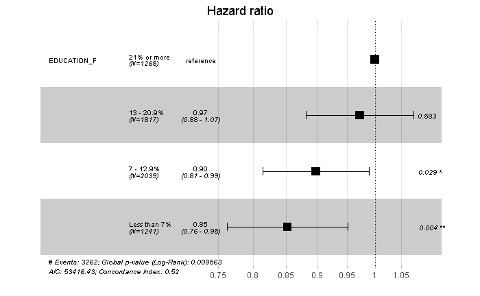

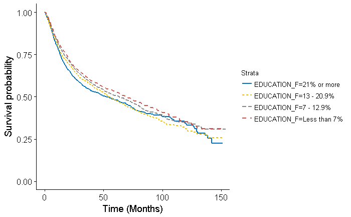

```r
uni_var(test_var = "EDUCATION_F", data_imp = data)
```

## Urban/Rural

```
_________________________________________________

## U_R_F
_________________________________________________
Call: survfit(formula = Surv(DX_LASTCONTACT_DEATH_MONTHS, PUF_VITAL_STATUS ==
    0) ~ U_R_F, data = data)

   194 observations deleted due to missingness
               n events median 0.95LCL 0.95UCL
U_R_F=Metro 5079   2588   60.4    56.1    65.3
U_R_F=Urban 1050    562   51.3    44.8    64.2
U_R_F=Rural  125     67   63.6    37.4    94.0

Call: survfit(formula = Surv(DX_LASTCONTACT_DEATH_MONTHS, PUF_VITAL_STATUS ==
    0) ~ U_R_F, data = data)

194 observations deleted due to missingness
                U_R_F=Metro
 time n.risk n.event survival std.err lower 95% CI upper 95% CI
   12   3919    1024    0.795 0.00571        0.784        0.807
   24   3035     619    0.666 0.00675        0.653        0.679
   36   2354     331    0.589 0.00717        0.576        0.604
   48   1857     178    0.542 0.00743        0.527        0.557
   60   1451     128    0.501 0.00769        0.486        0.517
  120    223     283    0.344 0.01028        0.324        0.365

                U_R_F=Urban
 time n.risk n.event survival std.err lower 95% CI upper 95% CI
   12    805     214    0.793  0.0126        0.769        0.818
   24    619     129    0.662  0.0149        0.633        0.692
   36    482      72    0.581  0.0158        0.551        0.613
   48    364      47    0.520  0.0165        0.489        0.554
   60    285      30    0.475  0.0170        0.443        0.510
  120     38      67    0.291  0.0235        0.248        0.341

                U_R_F=Rural
 time n.risk n.event survival std.err lower 95% CI upper 95% CI
   12     95      28    0.774  0.0375        0.704        0.852
   24     72      15    0.646  0.0436        0.566        0.737
   36     64       4    0.610  0.0448        0.528        0.704
```

[output cut: 15 more lines]

```
   (194 observations deleted due to missingness)

              coef exp(coef) se(coef)     z Pr(>|z|)
U_R_FUrban 0.06901   1.07145  0.04654 1.483    0.138
U_R_FRural 0.05022   1.05151  0.12375 0.406    0.685

           exp(coef) exp(-coef) lower .95 upper .95
U_R_FUrban     1.071     0.9333     0.978     1.174
U_R_FRural     1.052     0.9510     0.825     1.340

Concordance= 0.504  (se = 0.004 )
Rsquare= 0   (max possible= 1 )
Likelihood ratio test= 2.26  on 2 df,   p=0.3228
Wald test            = 2.29  on 2 df,   p=0.3177
Score (logrank) test = 2.29  on 2 df,   p=0.3176
```

```
Removed 1 rows containing missing values (geom_errorbar).
```

```
## Unadjusted Kaplan Meier Overall Survival Curve for:  U_R_F
```

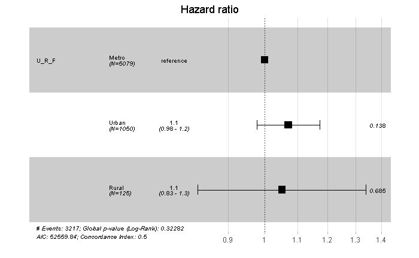

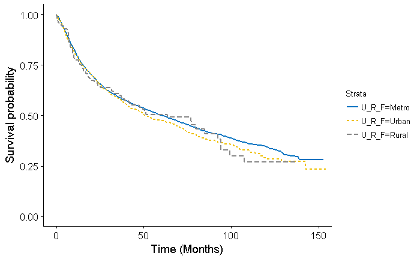

```r
uni_var(test_var = "U_R_F", data_imp = data)
```

## Comorbidities

```
_________________________________________________

## CDCC_TOTAL
_________________________________________________
Call: survfit(formula = Surv(DX_LASTCONTACT_DEATH_MONTHS, PUF_VITAL_STATUS ==
    0) ~ CDCC_TOTAL, data = data)

                n events median 0.95LCL 0.95UCL
CDCC_TOTAL=0 5106   2550   65.0    59.8    69.7
CDCC_TOTAL=1 1029    561   48.0    41.6    57.0
CDCC_TOTAL=2  228    149   25.3    22.9    35.8
CDCC_TOTAL=3   85     59   20.9    12.9    42.0

Call: survfit(formula = Surv(DX_LASTCONTACT_DEATH_MONTHS, PUF_VITAL_STATUS ==
    0) ~ CDCC_TOTAL, data = data)

                CDCC_TOTAL=0
 time n.risk n.event survival std.err lower 95% CI upper 95% CI
   12   3991     973    0.806 0.00558        0.795        0.817
   24   3122     610    0.679 0.00666        0.667        0.693
   36   2448     329    0.604 0.00710        0.590        0.618
   48   1920     191    0.554 0.00739        0.540        0.569
   60   1527     127    0.515 0.00765        0.500        0.530
  120    236     295    0.355 0.01027        0.335        0.375

                CDCC_TOTAL=1
 time n.risk n.event survival std.err lower 95% CI upper 95% CI
   12    755     243    0.760  0.0134        0.734        0.787
   24    559     129    0.625  0.0154        0.596        0.656
   36    431      57    0.557  0.0162        0.527        0.590
   48    330      41    0.500  0.0168        0.468        0.534
   60    243      26    0.457  0.0174        0.424        0.492
  120     33      61    0.268  0.0238        0.225        0.319

                CDCC_TOTAL=2
 time n.risk n.event survival std.err lower 95% CI upper 95% CI
   12    162      64    0.718  0.0299        0.662        0.779
   24    114      38    0.546  0.0333        0.484        0.615
   36     75      24    0.423  0.0340        0.362        0.496
   48     58       7    0.381  0.0342        0.320        0.455
```

[output cut: 25 more lines]

```
CDCC_TOTAL2 0.49908   1.64720  0.08437 5.915 3.32e-09 ***
CDCC_TOTAL3 0.68561   1.98499  0.13178 5.203 1.96e-07 ***
---
Signif. codes:  0 *** 0.001 ** 0.01 * 0.05 . 0.1   1

            exp(coef) exp(-coef) lower .95 upper .95
CDCC_TOTAL1     1.216     0.8227     1.109     1.332
CDCC_TOTAL2     1.647     0.6071     1.396     1.943
CDCC_TOTAL3     1.985     0.5038     1.533     2.570

Concordance= 0.526  (se = 0.004 )
Rsquare= 0.01   (max possible= 1 )
Likelihood ratio test= 62.85  on 3 df,   p=1.449e-13
Wald test            = 70.77  on 3 df,   p=2.887e-15
Score (logrank) test = 72.32  on 3 df,   p=1.332e-15
```

```
Removed 1 rows containing missing values (geom_errorbar).
```

```
## Unadjusted Kaplan Meier Overall Survival Curve for:  CDCC_TOTAL
```

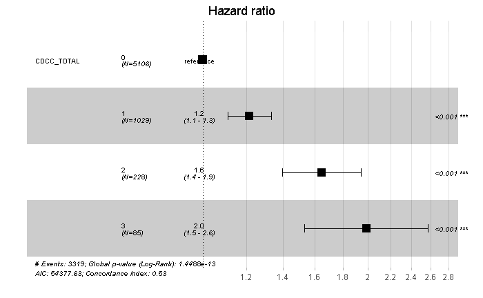

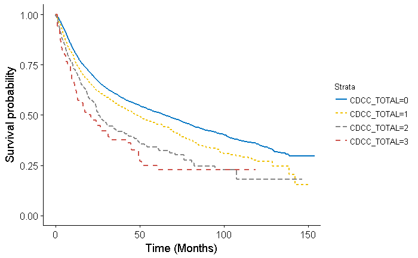

```r
uni_var(test_var = "CDCC_TOTAL", data_imp = data)
```

## Class (treatment at performing facility)

```
_________________________________________________

## CLASS_OF_CASE_F
_________________________________________________
Call: survfit(formula = Surv(DX_LASTCONTACT_DEATH_MONTHS, PUF_VITAL_STATUS ==
    0) ~ CLASS_OF_CASE_F, data = data)

      n  events  median 0.95LCL 0.95UCL
 6448.0  3319.0    58.0    54.3    63.4

Call: survfit(formula = Surv(DX_LASTCONTACT_DEATH_MONTHS, PUF_VITAL_STATUS ==
    0) ~ CLASS_OF_CASE_F, data = data)

 time n.risk n.event survival std.err lower 95% CI upper 95% CI
   12   4961    1311    0.794 0.00508        0.784        0.804
   24   3831     790    0.663 0.00600        0.652        0.675
   36   2977     417    0.587 0.00637        0.575        0.600
   48   2326     242    0.536 0.00661        0.524        0.549
   60   1822     163    0.496 0.00683        0.483        0.509
  120    271     367    0.334 0.00918        0.317        0.353




## Univariable Cox Proportional Hazard Model for:  CLASS_OF_CASE_F

Call:
coxph(formula = Surv(DX_LASTCONTACT_DEATH_MONTHS, PUF_VITAL_STATUS ==
    0) ~ CLASS_OF_CASE_F, data = data)

  n= 6448, number of events= 3319

                             coef exp(coef) se(coef)  z Pr(>|z|)
CLASS_OF_CASE_FAll_Part_Prim    0         1        0 NA       NA

                             exp(coef) exp(-coef) lower .95 upper .95
CLASS_OF_CASE_FAll_Part_Prim         1          1         1         1

Concordance= 0.5  (se = 0 )
Rsquare= 0   (max possible= 1 )
Likelihood ratio test= 0  on 1 df,   p=1
Wald test            = NaN  on 1 df,   p=NaN
Score (logrank) test = 0  on 1 df,   p=1
```

```
relative range of values =   0 * EPS, is small (axis 0)Removed 1 rows containing missing values (geom_errorbar).
```

```
## Unadjusted Kaplan Meier Overall Survival Curve for:  CLASS_OF_CASE_F
```

[figure not shown]

```r
uni_var(test_var = "CLASS_OF_CASE_F", data_imp = data)
```

## Year

```
_________________________________________________

## YEAR_OF_DIAGNOSIS
_________________________________________________
Call: survfit(formula = Surv(DX_LASTCONTACT_DEATH_MONTHS, PUF_VITAL_STATUS ==
    0) ~ YEAR_OF_DIAGNOSIS, data = data)

                         n events median 0.95LCL 0.95UCL
YEAR_OF_DIAGNOSIS=2004 524    339   52.3    41.8    65.5
YEAR_OF_DIAGNOSIS=2005 591    396   51.1    41.6    63.4
YEAR_OF_DIAGNOSIS=2006 544    342   56.1    43.0    70.0
YEAR_OF_DIAGNOSIS=2007 594    343   63.4    49.4    75.8
YEAR_OF_DIAGNOSIS=2008 599    332   61.4    45.9    80.2
YEAR_OF_DIAGNOSIS=2009 643    350   57.8    47.0    73.9
YEAR_OF_DIAGNOSIS=2010 560    289   57.4    43.5    73.9
YEAR_OF_DIAGNOSIS=2011 538    250     NA    48.5      NA
YEAR_OF_DIAGNOSIS=2012 606    255   54.0    51.3      NA
YEAR_OF_DIAGNOSIS=2013 621    229     NA    43.7      NA
YEAR_OF_DIAGNOSIS=2014 628    194     NA      NA      NA

Call: survfit(formula = Surv(DX_LASTCONTACT_DEATH_MONTHS, PUF_VITAL_STATUS ==
    0) ~ YEAR_OF_DIAGNOSIS, data = data)

                YEAR_OF_DIAGNOSIS=2004
 time n.risk n.event survival std.err lower 95% CI upper 95% CI
   12    391     107    0.789  0.0181        0.755        0.826
   24    318      68    0.651  0.0213        0.610        0.694
   36    275      42    0.565  0.0223        0.523        0.610
   48    255      18    0.528  0.0225        0.486        0.574
   60    226      24    0.478  0.0225        0.436        0.524
  120    111      67    0.318  0.0221        0.278        0.365

                YEAR_OF_DIAGNOSIS=2005
 time n.risk n.event survival std.err lower 95% CI upper 95% CI
   12    456     129    0.780  0.0171        0.747        0.815
   24    371      83    0.638  0.0199        0.600        0.678
   36    329      41    0.567  0.0205        0.528        0.609
   48    290      32    0.512  0.0207        0.473        0.554
   60    262      22    0.472  0.0208        0.433        0.515
  120    123      75    0.322  0.0203        0.285        0.364
```

[output cut: 96 more lines]

```
YEAR_OF_DIAGNOSIS2006    1.0223     0.9782    0.8788     1.189
YEAR_OF_DIAGNOSIS2007    0.9478     1.0551    0.8146     1.103
YEAR_OF_DIAGNOSIS2008    0.9574     1.0445    0.8215     1.116
YEAR_OF_DIAGNOSIS2009    0.9893     1.0108    0.8503     1.151
YEAR_OF_DIAGNOSIS2010    0.9534     1.0488    0.8131     1.118
YEAR_OF_DIAGNOSIS2011    0.9359     1.0684    0.7928     1.105
YEAR_OF_DIAGNOSIS2012    0.9050     1.1049    0.7670     1.068
YEAR_OF_DIAGNOSIS2013    0.8895     1.1243    0.7496     1.055
YEAR_OF_DIAGNOSIS2014    0.9705     1.0304    0.8102     1.163

Concordance= 0.513  (se = 0.005 )
Rsquare= 0.001   (max possible= 1 )
Likelihood ratio test= 6.01  on 10 df,   p=0.8141
Wald test            = 6  on 10 df,   p=0.8154
Score (logrank) test = 6  on 10 df,   p=0.815
```

```
Removed 1 rows containing missing values (geom_errorbar).
```

```
## Unadjusted Kaplan Meier Overall Survival Curve for:  YEAR_OF_DIAGNOSIS
```

```
This manual palette can handle a maximum of 10 values. You have supplied 11.
```

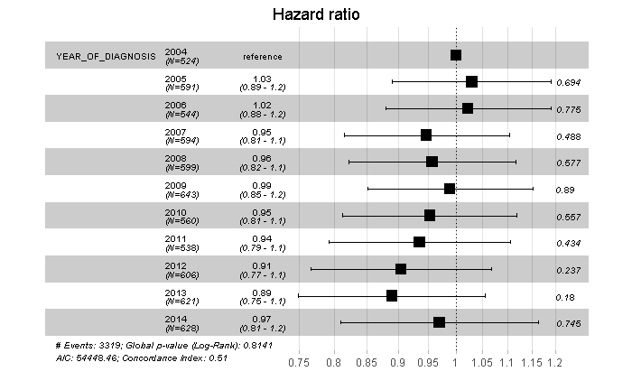

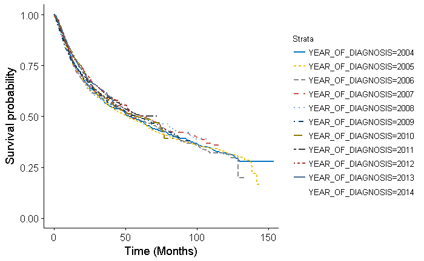

```r
uni_var(test_var = "YEAR_OF_DIAGNOSIS", data_imp = data)
```